# EpiCLim_Differential_expression_analysis_Transcriptomic_F0_Liver

Manon

2026-03-03

## Introduction

This script was used to perform differential expression analysis on adult zebrafish liver RNA-seq data following developmental exposure (2 hpf to 28 dpf) to combined climate stressors (acidification at pH 6.35, elevated temperature at 32°C) and PFOS (nominal 2 µg/L) in a 2×2×2 factorial design.

Analyses are performed on female liver samples (n=27, main analysis; n=25, sensitivity analysis). Male samples are excluded due to strong sexual dimorphism of the zebrafish liver transcriptome, in accordance with the overall study design.

Raw sequencing data are available on GEO (accession GSE######).

# Load count matrix

The raw count matrix was produced by the nf-core/rnaseq pipeline using STAR alignment and Salmon quantification, then summarized to gene-level counts using tximeta. Salmon produces non-integer counts, these were rounded to integers as required by DESeq2. Gene names and Ensembl IDs are stored separately at this stage: gene IDs are used as row names throughout the analysis (unique identifiers), while gene names are retained for annotation of results later.

```r
counts <- openxlsx::read.xlsx("Raw_counts_transcripto_liver_females.xlsx")

# Save gene names separately for annotation later
genes_names<-counts$gene_name
counts$gene_name<-NULL

# Set gene_id as rownames
rownames(counts)<-counts$gene_id
counts$gene_id<-NULL

# Round counts to integers (remove decimals)
counts<-round(counts)

# Confirm the dimensions of the final matrix with rows = genes and columns = samples.
dim(counts)
```

```
## [1] 32520    28
```

# Load metadata

The metadata file contains one row per sample with all relevant biological and technical variables knowns: condition, sex, exposure batch, RIN score, duplication rate, 5’-3’ bias, and proper pairs percentage. Setting sample names as row names is important as it allows direct indexing between the count matrix and metadata throughout the analysis. The final check confirms that every sample in the count matrix has a corresponding entry in the metadata –> must return TRUE before proceeding further.

```r
metadata <- openxlsx::read.xlsx("metadata_females.xlsx")

# Set sample names as row names for direct indexing with count matrix
rownames(metadata) <- metadata$sample

# Check that all sample names match with the count matrix
all(colnames(counts) %in% metadata$sample)
```

```
## [1] TRUE
```

# PCA females

A rlog transformation and set of PCA were performed to assess variability within the female samples. Each PC was correlated with biological and technical variables to understand what drives sample separation.

```r
#DESEQ2 object
dds_f <- DESeqDataSetFromMatrix(
  countData = counts,
  colData   = metadata,
  design    = ~ 1
)
```

```r
# Estimate size factors
dds_explore <- estimateSizeFactors(dds_f)

# Add to metadata
metadata$size_factor <- sizeFactors(dds_explore)[rownames(metadata)]

# rlog trasnformation
rld_f <- rlog(dds_f, blind = TRUE)

# Extraction of PCA coordinates
pca_f <- plotPCA(rld_f,
                 intgroup = c("condition"),
                 returnData = TRUE)
```

```
## using ntop=500 top features by variance
```

```r
# Add the metadata variables
pca_f$RIN          <- as.numeric(metadata[pca_f$name, "RIN"])
pca_f$exposure     <- as.factor(metadata[pca_f$name, "exposure"])
pca_f$size_factor  <- as.numeric(metadata[pca_f$name, "size_factor"])
pca_f$dup_rate     <- as.numeric(metadata[pca_f$name, "duplication_rate"])
pca_f$bias_5_3     <- as.numeric(metadata[pca_f$name, "five_three_prim_bias"])
pca_f$proper_pairs <- as.numeric(metadata[pca_f$name, "proper_pairs"])

# Get the variance explained by each PC
percentVar_f <- round(100 * attr(pca_f, "percentVar"))
cat("PC1 explains:", percentVar_f[1], "%\n")
```

```
## PC1 explains: 82 %
```

```r
cat("PC2 explains:", percentVar_f[2], "%\n")
```

```
## PC2 explains: 4 %
```

```r
# Update the labels for plots axis
x_lab <- paste0("PC1 (", percentVar_f[1], "%)")
y_lab <- paste0("PC2 (", percentVar_f[2], "%)")

# --- PCA according to biological variables ---

# Conditions in females
#Base for all plots
theme_pca <- theme_minimal() +
  theme(plot.title = element_text(size = 11, face = "bold"))

p_condition_f <- ggplot(pca_f,
                      aes(x = PC1, y = PC2,
                          color = condition,
                          label = name)) +
  geom_point(size = 3) +
  labs(x = x_lab, y = y_lab, title = "A — Condition") +
  theme_pca

# ANOVA
summary(aov(PC1 ~ condition, data = pca_f))
```

```
##             Df Sum Sq Mean Sq F value Pr(>F)
## condition    7  12723    1818   0.684  0.684
## Residuals   20  53158    2658
```

```r
summary(aov(PC2 ~ condition, data = pca_f))
```

```
##             Df Sum Sq Mean Sq F value Pr(>F)
## condition    7  855.9   122.3   0.957  0.488
## Residuals   20 2556.1   127.8
```

```r
# Exposure batch in females
pca_f$exposure <- as.factor(metadata[pca_f$name, "exposure"])
p_exposure_f <- ggplot(pca_f,
                     aes(x = PC1, y = PC2,
                         color = exposure,
                         label = name)) +
  geom_point(size = 3) +
  labs(x = x_lab, y = y_lab, title = "C — Exposure batch") +
  theme_pca

# Correlation
cor.test(pca_f$PC1, as.numeric(as.factor(pca_f$exposure)))
```

```
##
##  Pearson's product-moment correlation
##
## data:  pca_f$PC1 and as.numeric(as.factor(pca_f$exposure))
## t = -1.5253, df = 26, p-value = 0.1393
## alternative hypothesis: true correlation is not equal to 0
## 95 percent confidence interval:
##  -0.59594783  0.09684159
## sample estimates:
##        cor
## -0.2865896
```

```r
cor.test(pca_f$PC2, as.numeric(as.factor(pca_f$exposure)))
```

```
##
##  Pearson's product-moment correlation
##
## data:  pca_f$PC2 and as.numeric(as.factor(pca_f$exposure))
## t = -2.0415, df = 26, p-value = 0.05147
## alternative hypothesis: true correlation is not equal to 0
## 95 percent confidence interval:
##  -0.654067952  0.001610294
## sample estimates:
##        cor
## -0.3716899
```

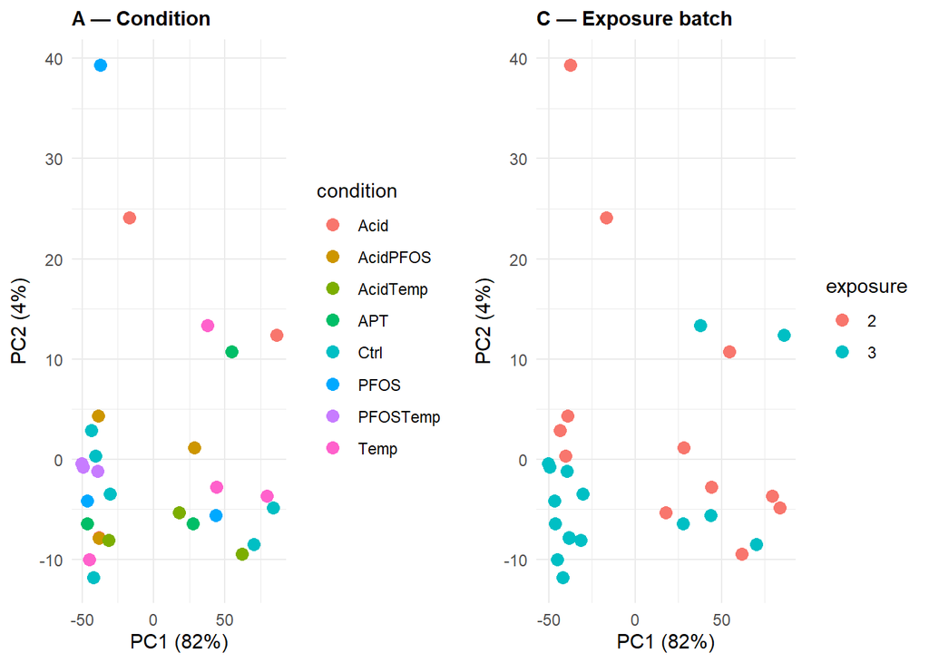

```r
# Figure 3 - plots PCA biological variables females
ggarrange(p_condition_f, p_exposure_f, ncol = 2)
```

```r
# --- PCA according to technical variables ---

#RIN
p_RIN_f <- ggplot(pca_f, aes(x = PC1, y = PC2, color = RIN)) +
  geom_point(size = 3) +
  scale_color_gradient(low = "red", high = "blue") +
  theme_pca +
  ggtitle("PCA colored by RIN")

# Correlation
cor.test(pca_f$PC1, pca_f$RIN)
```

```
##
##  Pearson's product-moment correlation
##
## data:  pca_f$PC1 and pca_f$RIN
## t = -1.4607, df = 26, p-value = 0.1561
## alternative hypothesis: true correlation is not equal to 0
## 95 percent confidence interval:
##  -0.5880465  0.1088775
## sample estimates:
##        cor
## -0.2753855
```

```r
cor.test(pca_f$PC2, pca_f$RIN)
```

```
##
##  Pearson's product-moment correlation
##
## data:  pca_f$PC2 and pca_f$RIN
## t = 0.22094, df = 26, p-value = 0.8269
## alternative hypothesis: true correlation is not equal to 0
## 95 percent confidence interval:
##  -0.3352012  0.4097487
## sample estimates:
##        cor
## 0.04328933
```

```r
# Duplication rate in females
p_duplication_f <- ggplot(pca_f,
                aes(x = PC1, y = PC2,
                    color = dup_rate,
                   )) +
  geom_point(size = 3) +
  scale_color_gradient(low = "blue", high = "red") +
  labs(x = x_lab, y = y_lab, title = "E — Duplication rate") +
  theme_pca

# Correlation
cor.test(pca_f$PC1, pca_f$dup_rate)
```

```
##
##  Pearson's product-moment correlation
##
## data:  pca_f$PC1 and pca_f$dup_rate
## t = -2.9546, df = 26, p-value = 0.006569
## alternative hypothesis: true correlation is not equal to 0
## 95 percent confidence interval:
##  -0.7366508 -0.1578011
## sample estimates:
##        cor
## -0.5013618
```

```r
cor.test(pca_f$PC2, pca_f$dup_rate)
```

```
##
##  Pearson's product-moment correlation
##
## data:  pca_f$PC2 and pca_f$dup_rate
## t = 0.57729, df = 26, p-value = 0.5687
## alternative hypothesis: true correlation is not equal to 0
## 95 percent confidence interval:
##  -0.2719961  0.4660148
## sample estimates:
##       cor
## 0.1124964
```

```r
# Size factors in females
p_sf_f <- ggplot(pca_f,
               aes(x = PC1, y = PC2,
                   color = size_factor,
                   )) +
  geom_point(size = 3) +
  scale_color_gradient(low = "purple", high = "yellow") +
  labs(x = x_lab, y = y_lab, title = "F — Size factor") +
  theme_pca

# Correlation
cor.test(pca_f$PC1, pca_f$size_factor)
```

```
##
##  Pearson's product-moment correlation
##
## data:  pca_f$PC1 and pca_f$size_factor
## t = 4.2981, df = 26, p-value = 0.0002141
## alternative hypothesis: true correlation is not equal to 0
## 95 percent confidence interval:
##  0.3573550 0.8203334
## sample estimates:
##       cor
## 0.6445058
```

```r
cor.test(pca_f$PC2, pca_f$size_factor)
```

```
##
##  Pearson's product-moment correlation
##
## data:  pca_f$PC2 and pca_f$size_factor
## t = 0.12374, df = 26, p-value = 0.9025
## alternative hypothesis: true correlation is not equal to 0
## 95 percent confidence interval:
##  -0.3520032  0.3937727
## sample estimates:
##        cor
## 0.02425965
```

```r
# 5'-3' bias females
p_bias_f <- ggplot(pca_f,
                 aes(x = PC1, y = PC2,
                     color = bias_5_3,
                     )) +
  geom_point(size = 3) +
  scale_color_gradient(low = "blue", high = "red") +
  labs(x = x_lab, y = y_lab, title = "G — 5'-3' bias") +
  theme_pca

# Correlation
cor.test(pca_f$PC1, pca_f$bias_5_3)
```

```
##
##  Pearson's product-moment correlation
##
## data:  pca_f$PC1 and pca_f$bias_5_3
## t = -1.3545, df = 26, p-value = 0.1872
## alternative hypothesis: true correlation is not equal to 0
## 95 percent confidence interval:
##  -0.5747632  0.1286616
## sample estimates:
##       cor
## -0.256739
```

```r
cor.test(pca_f$PC2, pca_f$bias_5_3)
```

```
##
##  Pearson's product-moment correlation
##
## data:  pca_f$PC2 and pca_f$bias_5_3
## t = 1.3508, df = 26, p-value = 0.1884
## alternative hypothesis: true correlation is not equal to 0
## 95 percent confidence interval:
##  -0.1293571  0.5742893
## sample estimates:
##       cor
## 0.2560782
```

```r
# Proper pairs females
p_ppairs_f <- ggplot(pca_f,
               aes(x = PC1, y = PC2,
                   color = proper_pairs,
                   )) +
  geom_point(size = 3) +
  scale_color_gradient(low = "red", high = "blue") +
  labs(x = x_lab, y = y_lab, title = "H — Proper pairs") +
  theme_pca

# Correlation
cor.test(pca_f$PC1, pca_f$proper_pairs)
```

```
##
##  Pearson's product-moment correlation
##
## data:  pca_f$PC1 and pca_f$proper_pairs
## t = 2.5528, df = 26, p-value = 0.0169
## alternative hypothesis: true correlation is not equal to 0
## 95 percent confidence interval:
##  0.08956259 0.70329402
## sample estimates:
##       cor
## 0.4476808
```

```r
cor.test(pca_f$PC2, pca_f$proper_pairs)
```

```
##
##  Pearson's product-moment correlation
##
## data:  pca_f$PC2 and pca_f$proper_pairs
## t = -0.76912, df = 26, p-value = 0.4488
## alternative hypothesis: true correlation is not equal to 0
## 95 percent confidence interval:
##  -0.4946988  0.2371225
## sample estimates:
##        cor
## -0.1491488
```

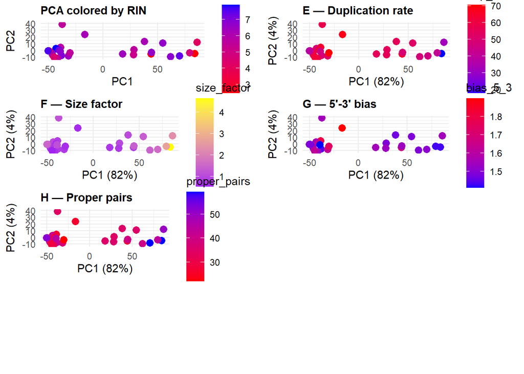

```r
# Arrange all technical plots together
ggarrange(p_RIN_f,p_duplication_f, p_sf_f, p_bias_f, p_ppairs_f, ncol = 2, nrow = 4)
```

```r
# Build the correlation summary table
pca_cor_table_f <- data.frame(
  Variable = c("Condition","Exposure batch", "RIN", "Duplication rate", "Size factor", "5'-3' bias",
               "Proper pairs"),
  PC1_cor_score = c(0.684,-0.287, -0.275,-0.501, 0.644, -0.257, 0.448),
  PC1_p_value = c(0.684, 0.139, 0.156, 0.007, 0.0002, 0.187, 0.017),
  PC1_sig = c("ns", "ns", "ns", "*", "**", "ns", "*"),
  PC2_r_cor_score = c(0.957,-0.372, 0.043, 0.112, 0.021, 0.256, -0.149),
  PC2_p_value = c(0.488, 0.051, 0.827, 0.569, 0.916, 0.188, 0.449),
  PC2_sig = c("ns", "borderline", "ns", "ns", "ns", "ns", "ns"),
  Overall_significance = c("none","bordeline","none","strong","strong","none","moderate"),
  stringsAsFactors = FALSE
)

kable(pca_cor_table_f,
      col.names = c("Variable", "r/F", "p-value", "Sig.",
                    "r/F", "p-value", "Sig.", "Overall significance"),
      caption = "Correlation of technical and biological variables
      with principal components (rlog transformation, n=28), Strong = significant in both PCs or |r| > 0.5 in one PC, Moderate = significant in one PC with |r| 0.3–0.5, None = not significant in either PC.",
      align = c("l","r","r","c","r","r","c","l")) %>%
  kable_styling(bootstrap_options = c("striped", "hover", "condensed"),
                full_width = FALSE) %>%
  add_header_above(c(" " = 1,
                     "PC1 (76%)" = 3,
                     "PC2 (6%)" = 3,
                     " " = 1))
```

Correlation of technical and biological variables with principal components (rlog transformation, n=28), Strong = significant in both PCs or |r| > 0.5 in one PC, Moderate = significant in one PC with |r| 0.3–0.5, None = not significant in either PC.

Variable

r/F

p-value

Sig.

r/F

p-value

Sig.

Overall significance

Condition

0.684

0.6840

ns

0.957

0.488

ns

none

Exposure batch

-0.287

0.1390

ns

-0.372

0.051

borderline

bordeline

RIN

-0.275

0.1560

ns

0.043

0.827

ns

none

Duplication rate

-0.501

0.0070

0.112

0.569

ns

strong

Size factor

0.644

0.0002

0.021

ns

strong

5’-3’ bias

-0.257

0.1870

ns

0.256

0.188

ns

none

Proper pairs

0.448

0.0170

-0.149

0.449

ns

moderate

PC1 was significantly driven by size factor, duplication rate, and proper pairs. Exposure replicate and RIN were not significant. PC2 showed no significant associations with any variable, with exposure replicate borderline. Experimental condition remained non-significant on both PCs. We observe a technical gradient along PC1.

```r
# Check which samples are driving PC1
pca_f_sorted <- pca_f[order(pca_f$PC1), ]

cat("\nTop 5 PC1 (most positive):\n")
```

```
##
## Top 5 PC1 (most positive):
```

```r
print(pca_f_sorted[(nrow(pca_f_sorted)-4):nrow(pca_f_sorted),
                    c("name", "condition", "PC1",
                      "size_factor", "dup_rate")])
```

```
##                      name condition      PC1 size_factor dup_rate
## AcidTemp56F2 AcidTemp56F2  AcidTemp 61.73535    1.470700     47.6
## Ctrl7F3           Ctrl7F3      Ctrl 70.04500    1.623559     45.8
## Temp35F2         Temp35F2      Temp 79.31820    2.714961     41.1
## Ctrl8F2           Ctrl8F2      Ctrl 83.77702    4.633764     17.2
## Acid21F3         Acid21F3      Acid 86.09435    2.307815     32.3
```

```r
cat("Bottom 5 PC1 (most negative):\n")
```

```
## Bottom 5 PC1 (most negative):
```

```r
print(pca_f_sorted[1:5, c("name", "condition", "PC1",
                            "size_factor", "dup_rate")])
```

```
##                      name condition       PC1 size_factor dup_rate
## PFOSTemp80F3 PFOSTemp80F3  PFOSTemp -50.42833   1.5173041     38.3
## PFOSTemp79F3 PFOSTemp79F3  PFOSTemp -49.56415   1.0993459     55.7
## PFOS42F3         PFOS42F3      PFOS -46.65862   0.7733328     57.2
## APT93F3           APT93F3       APT -46.49974   0.7224433     45.8
## Temp32F3         Temp32F3      Temp -45.00947   0.5111280     62.7
```

```r
# Note: Ctrl8F3 is not an extreme outlier, here the most extreme samples are Ctrl8F2 and Acid21F3

# Check the different variables for the samples flagged as outliers
cat("\nQC metrics for flagged samples:\n")
```

```
##
## QC metrics for flagged samples:
```

```r
pca_f[pca_f$name %in% c("Ctrl8F3", "Ctrl8F2",
                          "Acid18F2", "AcidPFOS67F2","Acid21F3"),
      c("name", "condition", "PC1", "PC2",
        "size_factor", "dup_rate", "bias_5_3",
        "proper_pairs")]
```

```
##                      name condition       PC1       PC2 size_factor dup_rate
## Acid18F2         Acid18F2      Acid -16.75018 24.125489   0.6003863     67.5
## Acid21F3         Acid21F3      Acid  86.09435 12.405187   2.3078150     32.3
## AcidPFOS67F2 AcidPFOS67F2  AcidPFOS -38.93513  4.315649   0.8483956     64.8
## Ctrl8F2           Ctrl8F2      Ctrl  83.77702 -4.823893   4.6337636     17.2
## Ctrl8F3           Ctrl8F3      Ctrl -30.47290 -3.460282   0.6227710     70.5
##              bias_5_3 proper_pairs
## Acid18F2         1.90         26.2
## Acid21F3         1.55         50.0
## AcidPFOS67F2     1.80         26.4
## Ctrl8F2          1.43         59.4
## Ctrl8F3          1.74         21.9
```

```r
# Sensitivity check: what happen when the worst outliers are removed:
meta_f_clean <- metadata[!rownames(metadata) %in%
                               c("Ctrl8F2", "Ctrl8F3"), ]
counts_f_clean <- counts[, rownames(meta_f_clean)]

dds_f_clean <- DESeqDataSetFromMatrix(
  countData = counts_f_clean,
  colData   = meta_f_clean,
  design    = ~ 1
)
```

```r
rld_f_clean <- rlog(dds_f_clean, blind = TRUE)

pca_f_clean <- plotPCA(rld_f_clean,
                        intgroup = c("condition", "sex"),
                        returnData = TRUE)
```

```
## using ntop=500 top features by variance
```

```r
percentVar_clean <- round(100 * attr(pca_f_clean, "percentVar"))
cat("PC1:", percentVar_clean[1], "%\n")
```

```
## PC1: 80 %
```

```r
cat("PC2:", percentVar_clean[2], "%\n")
```

```
## PC2: 5 %
```

```r
# PC are not improved

# Check size factor correlation
pca_f_clean$size_factor <- meta_f_clean[pca_f_clean$name, "size_factor"]
cor.test(pca_f_clean$PC1, pca_f_clean$size_factor)
```

```
##
##  Pearson's product-moment correlation
##
## data:  pca_f_clean$PC1 and pca_f_clean$size_factor
## t = 4.3325, df = 24, p-value = 0.0002268
## alternative hypothesis: true correlation is not equal to 0
## 95 percent confidence interval:
##  0.3700854 0.8354404
## sample estimates:
##       cor
## 0.6624701
```

```r
# size factor correlation unchanged (r = 0.67)
```

```r
# Remove ALL flagged samples as:
# Ctrl8F3: fails 3 QC metrics
# Ctrl8F2: extreme size factor
# Acid18F2: highest 5'-3' bias, low proper pairs
# AcidPFOS67F2: elevated 5'-3' bias, low proper pairs
# Acid21F3: extreme PC1 position

meta_f_allflagged <- metadata[
  !rownames(metadata) %in%
    c("Ctrl8F2", "Ctrl8F3",
      "Acid18F2", "AcidPFOS67F2",
      "Acid21F3"), ]

counts_f_allflagged <- counts[, rownames(meta_f_allflagged)]

dds_f_allflagged <- DESeqDataSetFromMatrix(
  countData = counts_f_allflagged,
  colData   = meta_f_allflagged,
  design    = ~ 1)
rld_f_allflagged <- rlog(dds_f_allflagged, blind = TRUE)

pca_f_allflagged <- plotPCA(rld_f_allflagged,
                             intgroup = c("condition", "sex"),
                             returnData = TRUE)
```

```
## using ntop=500 top features by variance
```

```r
percentVar_allflagged <- round(
  100 * attr(pca_f_allflagged, "percentVar"))
cat("After removing all flagged samples:\n")
```

```
## After removing all flagged samples:
```

```r
cat("PC1:", percentVar_allflagged[1], "%\n")
```

```
## PC1: 80 %
```

```r
cat("PC2:", percentVar_allflagged[2], "%\n")
```

```
## PC2: 5 %
```

```r
pca_f_allflagged$size_factor <- as.numeric(
  meta_f_allflagged[pca_f_allflagged$name, "size_factor"])

cor.test(pca_f_allflagged$PC1, pca_f_allflagged$size_factor)
```

```
##
##  Pearson's product-moment correlation
##
## data:  pca_f_allflagged$PC1 and pca_f_allflagged$size_factor
## t = 3.3611, df = 21, p-value = 0.002956
## alternative hypothesis: true correlation is not equal to 0
## 95 percent confidence interval:
##  0.2370082 0.8069155
## sample estimates:
##       cor
## 0.5914304
```

```r
# Check remaining sample sizes per condition
cat("\nSample sizes after removing all flagged samples:\n")
```

```
##
## Sample sizes after removing all flagged samples:
```

```r
print(table(meta_f_allflagged$condition))
```

```
##
##     Acid AcidPFOS AcidTemp      APT     Ctrl     PFOS PFOSTemp     Temp
##        1        2        3        3        4        3        3        4
```

To inform individual exclusion decisions, the quality metrics of all flagged samples were compared to the dataset median. The full distribution of 5’-3’ bias was also examined to identify natural breaks in the data that could justify exclusion thresholds.

```r
# Get the dataset medians as reference
cat("Dataset medians (n=28 females):\n")
```

```
## Dataset medians (n=28 females):
```

```r
cat("Duplication rate:", median(metadata$duplication_rate), "\n")
```

```
## Duplication rate: 54.75
```

```r
cat("5-3 bias:", median(metadata$five_three_prim_bias), "\n")
```

```
## 5-3 bias: 1.54
```

```r
cat("Proper pairs:", median(metadata$proper_pairs), "\n")
```

```
## Proper pairs: 35.6
```

```r
# Get all the flagged samples to compare to medians
cat("\nFlagged sample metrics:\n")
```

```
##
## Flagged sample metrics:
```

```r
flagged_samples <- c("Ctrl8F2", "Ctrl8F3",
                     "Acid18F2", "AcidPFOS67F2", "Acid21F3")

metadata[flagged_samples,
             c("condition", "duplication_rate",
               "five_three_prim_bias", "proper_pairs")]
```

```
##              condition duplication_rate five_three_prim_bias proper_pairs
## Ctrl8F2           Ctrl             17.2                 1.43         59.4
## Ctrl8F3           Ctrl             70.5                 1.74         21.9
## Acid18F2          Acid             67.5                 1.90         26.2
## AcidPFOS67F2  AcidPFOS             64.8                 1.80         26.4
## Acid21F3          Acid             32.3                 1.55         50.0
```

```r
# Full distribution of 5'-3' bias to assess outliers
cat("\nFull distribution of 5'-3' bias (sorted):\n")
```

```
##
## Full distribution of 5'-3' bias (sorted):
```

```r
sort(metadata$five_three_prim_bias)
```

```
##  [1] 1.41 1.43 1.43 1.45 1.45 1.45 1.47 1.49 1.49 1.49 1.49 1.51 1.54 1.54 1.54
## [16] 1.54 1.55 1.55 1.55 1.55 1.56 1.62 1.63 1.67 1.69 1.74 1.80 1.90
```

# Outlier assessment and sample exclusion decision

**Acid21F3** shows an extreme PC1 position (+86.1) but its quality metrics are acceptable (duplication 32.3%, 5’-3’ bias 1.55, proper pairs 50.0%). Its PCA position likely reflects biological variability rather than technical failure. Acid21F3 is therefore **retained**.

**Ctrl8F3** fails on three quality metrics simultaneously: duplication rate 70.5% (dataset median 54.75%), 5’-3’ bias 1.74 (dataset median 1.54), and proper pairs 21.9% (dataset median 35.6%). The 5’-3’ bias distribution revealed a natural break after 1.69, with Ctrl8F3 clearly separated from the main cluster. As a control sample, its removal leaves n=5 control females which is sufficient. Ctrl8F3 is **excluded** from all analyses.

**Acid18F2** shows elevated 5’-3’ bias (1.90 — highest in the dataset) and low proper pairs (26.2%). However its removal would reduce the Acid condition to n=2 females, which is insufficient for reliable dispersion estimation in DESeq2. Acid18F2 is **retained in the main analysis but excluded in the sensitivity analysis**.

**AcidPFOS67F2** shows elevated 5’-3’ bias (1.80) and low proper pairs (26.4%). Same reasoning as Acid18F2: removal would reduce AcidPFOS to n=2. AcidPFOS67F2 is **retained in the main analysis but excluded in the sensitivity analysis**.

# Final sample selection

Based on the outlier assessment above, two sample sets were defined for all downstream analyses. The main analysis retained all samples except Ctrl8F3. The sensitivity analysis additionally excluded Acid18F2 and AcidPFOS67F2 to assess whether borderline samples affect the conclusions.

```r
# Main analysis
meta_f_main <- metadata[
  rownames(metadata) != "Ctrl8F3", ]
counts_f_main <- counts[, rownames(meta_f_main)]

# Sensitivity analysis: females, all three flagged samples removed
meta_f_sensitivity <- metadata[
  !rownames(metadata) %in%
    c("Ctrl8F3", "Acid18F2", "AcidPFOS67F2"), ]
counts_f_sensitivity <- counts[, rownames(meta_f_sensitivity)]

# Check sample distributions
cat("MAIN n =", nrow(meta_f_main), "\n")
```

```
## MAIN n = 27
```

```r
print(table(meta_f_main$condition, meta_f_main$exposure))
```

```
##
##            2 3
##   Acid     1 2
##   AcidPFOS 2 1
##   AcidTemp 2 1
##   APT      1 2
##   Ctrl     3 2
##   PFOS     1 2
##   PFOSTemp 0 3
##   Temp     2 2
```

```r
cat("SENSITIVITY n =", nrow(meta_f_sensitivity), "\n")
```

```
## SENSITIVITY n = 25
```

```r
print(table(meta_f_sensitivity$condition, meta_f_sensitivity$exposure))
```

```
##
##            2 3
##   Acid     0 2
##   AcidPFOS 1 1
##   AcidTemp 2 1
##   APT      1 2
##   Ctrl     3 2
##   PFOS     1 2
##   PFOSTemp 0 3
##   Temp     2 2
```

# DESeq2 - main analysis

The DESeq2 model includes the exposure batch as a covariate and the exposure conditions as the variable of interest (~ exposure + condition). Including the exposure batch accounts for systematic differences between the two independent biological replicate experiments. For the condition comparison, control is the reference group for all pairwise comparisons. Genes with very low counts were removed before fitting the model. We retained only the genes with at least 10 counts in a minimum of 3 samples. This pre-filtering step improves statistical power by reducing the number of tests submitted to multiple testing correction.

```r
# Set control as reference
meta_f_main$condition <- relevel(
  factor(meta_f_main$condition), ref = "Ctrl")
meta_f_main$exposure  <- factor(meta_f_main$exposure)

# Build the DESeq2 object
dds_main_f <- DESeqDataSetFromMatrix(countData = counts_f_main,
                              colData = meta_f_main,
                              design= ~ exposure + condition)
# Filter genes with low count
# Keep genes with >= 10 counts in at least 3 samples
keep <- rowSums(counts(dds_main_f) >= 10) >= 3
dds_main_f <- dds_main_f[keep, ]

cat("Genes before filtering:", nrow(counts_f_main), "\n")
```

```
## Genes before filtering: 32520
```

```r
cat("Genes after filtering:", nrow(dds_main_f), "\n")
```

```
## Genes after filtering: 15989
```

```r
# 32520 -> 15989 genes retained (49%) — standard for liver RNA-seq
```

# Run the DESEQ model

```r
dds_main_f <- DESeq(dds_main_f)
```

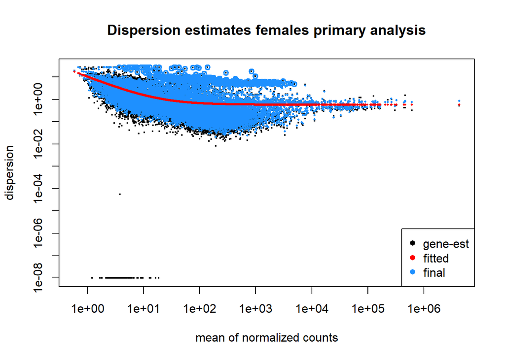

```r
# Dispersion estimates diagnostic plot
plotDispEsts(dds_main_f,
             main = "Dispersion estimates females primary analysis")
```

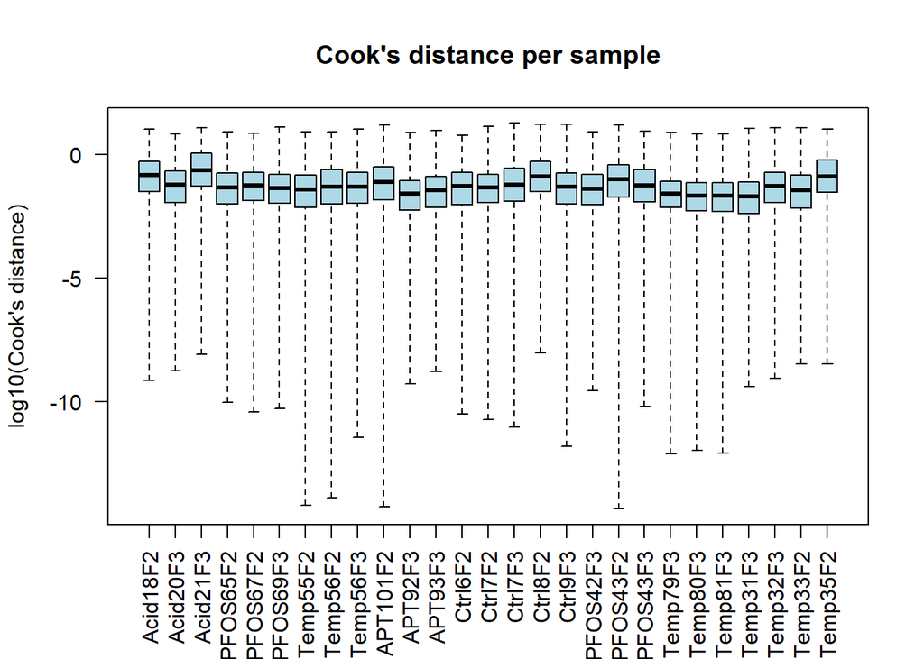

```r
# Cook's distance
boxplot(log10(assays(dds_main_f)[["cooks"]]),
        range = 0,
        las = 2,
        main = "Cook's distance per sample",
        ylab = "log10(Cook's distance)",
        col = "lightblue")
```

```r
# Check model terms
cat("\nModel terms:\n")
```

```
##
## Model terms:
```

```r
print(resultsNames(dds_main_f))
```

```
## [1] "Intercept"                  "exposure_3_vs_2"
## [3] "condition_Acid_vs_Ctrl"     "condition_AcidPFOS_vs_Ctrl"
## [5] "condition_AcidTemp_vs_Ctrl" "condition_APT_vs_Ctrl"
## [7] "condition_PFOS_vs_Ctrl"     "condition_PFOSTemp_vs_Ctrl"
## [9] "condition_Temp_vs_Ctrl"
```

Cook’s distance per sample showed comparable distributions across all retained samples, indicating that no single sample exerts disproportionate influence on the differential expression results across the transcriptome.

# Comparisons betwen each condition and control

Pairwise Wald tests were performed for each condition against Control with independent filtering: DESeq2 automatically finds the optimal count threshold per comparison that maximizes the number of genes passing multiple testing correction. The Cook’s distance cutoff was also enabled (setting adjusted p-values to NA for genes with extreme outlier counts in individual samples). P-adjusted p-values are obtained after applying Benjamini-Hochberg correction.

```r
# Check comparisons by extracting Wald test results for each condition vs. Control
res_Acid <- results(dds_main_f,
                    contrast = c("condition", "Acid", "Ctrl"),
                    independentFiltering = TRUE,
                    cooksCutoff = TRUE)
res_Temp    <- results(dds_main_f,
                       contrast = c("condition", "Temp", "Ctrl"),
                       independentFiltering = TRUE,
                       cooksCutoff = TRUE)

res_PFOS    <- results(dds_main_f,
                       contrast = c("condition", "PFOS", "Ctrl"),
                       independentFiltering = TRUE,
                       cooksCutoff = TRUE)

res_AcidTemp <- results(dds_main_f,
                        contrast = c("condition", "AcidTemp", "Ctrl"),
                        independentFiltering = TRUE,
                        cooksCutoff = TRUE)

res_PFOSTemp <- results(dds_main_f,
                        contrast = c("condition", "PFOSTemp", "Ctrl"),
                        independentFiltering = TRUE,
                        cooksCutoff = TRUE)

res_AcidPFOS <- results(dds_main_f,
                        contrast = c("condition", "AcidPFOS", "Ctrl"),
                        independentFiltering = TRUE,
                        cooksCutoff = TRUE)

res_APT     <- results(dds_main_f,
                       contrast = c("condition", "APT", "Ctrl"),
                       independentFiltering = TRUE,
                       cooksCutoff = TRUE)

# Summaries of results at p.adj < 0.05
summary(res_Acid, alpha = 0.05)
```

```
##
## out of 15989 with nonzero total read count
## adjusted p-value < 0.05
## LFC > 0 (up)       : 2, 0.013%
## LFC < 0 (down)     : 3, 0.019%
## outliers [1]       : 184, 1.2%
## low counts [2]     : 0, 0%
## (mean count < 1)
## [1] see 'cooksCutoff' argument of ?results
## [2] see 'independentFiltering' argument of ?results
```

```r
summary(res_Temp, alpha = 0.05)
```

```
##
## out of 15989 with nonzero total read count
## adjusted p-value < 0.05
## LFC > 0 (up)       : 3, 0.019%
## LFC < 0 (down)     : 1, 0.0063%
## outliers [1]       : 184, 1.2%
## low counts [2]     : 0, 0%
## (mean count < 1)
## [1] see 'cooksCutoff' argument of ?results
## [2] see 'independentFiltering' argument of ?results
```

```r
summary(res_PFOS, alpha = 0.05)
```

```
##
## out of 15989 with nonzero total read count
## adjusted p-value < 0.05
## LFC > 0 (up)       : 16, 0.1%
## LFC < 0 (down)     : 46, 0.29%
## outliers [1]       : 184, 1.2%
## low counts [2]     : 606, 3.8%
## (mean count < 3)
## [1] see 'cooksCutoff' argument of ?results
## [2] see 'independentFiltering' argument of ?results
```

```r
summary(res_AcidTemp, alpha = 0.05)
```

```
##
## out of 15989 with nonzero total read count
## adjusted p-value < 0.05
## LFC > 0 (up)       : 48, 0.3%
## LFC < 0 (down)     : 78, 0.49%
## outliers [1]       : 184, 1.2%
## low counts [2]     : 0, 0%
## (mean count < 1)
## [1] see 'cooksCutoff' argument of ?results
## [2] see 'independentFiltering' argument of ?results
```

```r
summary(res_PFOSTemp, alpha = 0.05)
```

```
##
## out of 15989 with nonzero total read count
## adjusted p-value < 0.05
## LFC > 0 (up)       : 741, 4.6%
## LFC < 0 (down)     : 1481, 9.3%
## outliers [1]       : 184, 1.2%
## low counts [2]     : 606, 3.8%
## (mean count < 3)
## [1] see 'cooksCutoff' argument of ?results
## [2] see 'independentFiltering' argument of ?results
```

```r
summary(res_AcidPFOS, alpha = 0.05)
```

```
##
## out of 15989 with nonzero total read count
## adjusted p-value < 0.05
## LFC > 0 (up)       : 37, 0.23%
## LFC < 0 (down)     : 38, 0.24%
## outliers [1]       : 184, 1.2%
## low counts [2]     : 606, 3.8%
## (mean count < 3)
## [1] see 'cooksCutoff' argument of ?results
## [2] see 'independentFiltering' argument of ?results
```

```r
summary(res_APT, alpha = 0.05)
```

```
##
## out of 15989 with nonzero total read count
## adjusted p-value < 0.05
## LFC > 0 (up)       : 38, 0.24%
## LFC < 0 (down)     : 59, 0.37%
## outliers [1]       : 184, 1.2%
## low counts [2]     : 2126, 13%
## (mean count < 6)
## [1] see 'cooksCutoff' argument of ?results
## [2] see 'independentFiltering' argument of ?results
```

The 184 outlier genes detected in all comparisons reflect Cook’s distance filtering applied at the model level. These genes received NA adjusted p-values and were excluded from multiple testing correction.

# LFC shrinkage

LFC shrinkage was applied using the ashr method (Stephens 2017) to obtain reliable log2 fold change estimates. This reduces noisy fold change estimates from lowly expressed genes toward zero while leaving well-estimated fold changes from highly expressed genes unchanged. The shrinkage does not affect the statistical significance of results (padj values are not modified) but improves the reliability of fold change estimates used for filtering and visualization. This is important for datasets with small n per condition and high variability. The ashr method was selected over apeglm because it supports contrast-based comparisons between experimental conditions (like combination vs single stressor), while apeglm only allows coefficient based comparisons against the reference.

```r
# LFC shrinkage with ashr
resLFC_Acid <- lfcShrink(dds_main_f,
                          contrast = c("condition", "Acid", "Ctrl"),
                          type = "ashr")
resLFC_Temp <- lfcShrink(dds_main_f,
                          contrast = c("condition", "Temp", "Ctrl"),
                          type = "ashr")
resLFC_PFOS <- lfcShrink(dds_main_f,
                          contrast = c("condition", "PFOS", "Ctrl"),
                          type = "ashr")
resLFC_AcidTemp <- lfcShrink(dds_main_f,
                               contrast = c("condition", "AcidTemp", "Ctrl"),
                               type = "ashr")
resLFC_PFOSTemp <- lfcShrink(dds_main_f,
                               contrast = c("condition", "PFOSTemp", "Ctrl"),
                               type = "ashr")
resLFC_AcidPFOS <- lfcShrink(dds_main_f,
                               contrast = c("condition", "AcidPFOS", "Ctrl"),
                               type = "ashr")
resLFC_APT <- lfcShrink(dds_main_f,
                         contrast = c("condition", "APT", "Ctrl"),
                         type = "ashr")

# Verify all summaries match previous results
summary(resLFC_Acid, alpha = 0.05)
```

```
##
## out of 15989 with nonzero total read count
## adjusted p-value < 0.05
## LFC > 0 (up)       : 2, 0.013%
## LFC < 0 (down)     : 3, 0.019%
## outliers [1]       : 184, 1.2%
## low counts [2]     : 0, 0%
## (mean count < 1)
## [1] see 'cooksCutoff' argument of ?results
## [2] see 'independentFiltering' argument of ?results
```

```r
summary(resLFC_Temp, alpha = 0.05)
```

```
##
## out of 15989 with nonzero total read count
## adjusted p-value < 0.05
## LFC > 0 (up)       : 3, 0.019%
## LFC < 0 (down)     : 1, 0.0063%
## outliers [1]       : 184, 1.2%
## low counts [2]     : 0, 0%
## (mean count < 1)
## [1] see 'cooksCutoff' argument of ?results
## [2] see 'independentFiltering' argument of ?results
```

```r
summary(resLFC_PFOS, alpha = 0.05)
```

```
##
## out of 15989 with nonzero total read count
## adjusted p-value < 0.05
## LFC > 0 (up)       : 16, 0.1%
## LFC < 0 (down)     : 46, 0.29%
## outliers [1]       : 184, 1.2%
## low counts [2]     : 606, 3.8%
## (mean count < 3)
## [1] see 'cooksCutoff' argument of ?results
## [2] see 'independentFiltering' argument of ?results
```

```r
summary(resLFC_AcidTemp, alpha = 0.05)
```

```
##
## out of 15989 with nonzero total read count
## adjusted p-value < 0.05
## LFC > 0 (up)       : 48, 0.3%
## LFC < 0 (down)     : 78, 0.49%
## outliers [1]       : 184, 1.2%
## low counts [2]     : 0, 0%
## (mean count < 1)
## [1] see 'cooksCutoff' argument of ?results
## [2] see 'independentFiltering' argument of ?results
```

```r
summary(resLFC_PFOSTemp, alpha = 0.05)
```

```
##
## out of 15989 with nonzero total read count
## adjusted p-value < 0.05
## LFC > 0 (up)       : 741, 4.6%
## LFC < 0 (down)     : 1481, 9.3%
## outliers [1]       : 184, 1.2%
## low counts [2]     : 606, 3.8%
## (mean count < 3)
## [1] see 'cooksCutoff' argument of ?results
## [2] see 'independentFiltering' argument of ?results
```

```r
summary(resLFC_AcidPFOS, alpha = 0.05)
```

```
##
## out of 15989 with nonzero total read count
## adjusted p-value < 0.05
## LFC > 0 (up)       : 37, 0.23%
## LFC < 0 (down)     : 38, 0.24%
## outliers [1]       : 184, 1.2%
## low counts [2]     : 606, 3.8%
## (mean count < 3)
## [1] see 'cooksCutoff' argument of ?results
## [2] see 'independentFiltering' argument of ?results
```

```r
summary(resLFC_APT, alpha = 0.05)
```

```
##
## out of 15989 with nonzero total read count
## adjusted p-value < 0.05
## LFC > 0 (up)       : 38, 0.24%
## LFC < 0 (down)     : 59, 0.37%
## outliers [1]       : 184, 1.2%
## low counts [2]     : 2126, 13%
## (mean count < 6)
## [1] see 'cooksCutoff' argument of ?results
## [2] see 'independentFiltering' argument of ?results
```

# Get significant genes

Genes were considered differentially expressed if the adjusted p-value < 0.05 after Benjamini-Hochberg correction, and the log2 fold change ≥ log2(1.5), corresponding to a minimum 1.5-fold change in either direction. The log2(1.5) threshold was chosen as a biologically meaningful minimum effect size given the high within-group variability in this dataset. All results use shrunken LFC estimates from the previous step.

```r
# Get genes names
gene_annotations <- data.frame(
  gene_id   = rownames(counts),
  gene_name = genes_names,
  stringsAsFactors = FALSE
)
rownames(gene_annotations) <- gene_annotations$gene_id

# Check the annotation table looks correct
head(gene_annotations)
```

```
##                               gene_id gene_name
## ENSDARG00000101324 ENSDARG00000101324    apoa1b
## ENSDARG00000063905 ENSDARG00000063905    mt-co1
## ENSDARG00000015866 ENSDARG00000015866     apoa2
## ENSDARG00000038439 ENSDARG00000038439   fabp10a
## ENSDARG00000092170 ENSDARG00000092170     apoc1
## ENSDARG00000063908 ENSDARG00000063908    mt-co2
```

```r
# Create a function to get significant gene in each comparison
get_sig_genes <- function(res, condition_name,
                           padj_thresh = 0.05,
                           lfc_thresh = log2(1.5)) {

  res_df <- as.data.frame(res)
  res_df$gene_id   <- rownames(res_df)
  res_df$gene_name <- gene_annotations[rownames(res_df), "gene_name"]
  res_df$condition <- condition_name

  # Classify each gene
  res_df$direction <- "NS"  # default
  res_df$direction[is.na(res_df$padj)] <- "NA"
  res_df$direction[!is.na(res_df$padj) &
                 res_df$padj < padj_thresh &
                 res_df$log2FoldChange >= lfc_thresh] <- "UP"
  res_df$direction[!is.na(res_df$padj) &
                 res_df$padj < padj_thresh &
                 res_df$log2FoldChange <= -lfc_thresh] <- "DOWN"

  res_df[order(res_df$padj, na.last = TRUE), ]
}

# Apply to all vs Control comparisons
results_Acid     <- get_sig_genes(resLFC_Acid,     "Acid")
results_Temp     <- get_sig_genes(resLFC_Temp,     "Temp")
results_PFOS     <- get_sig_genes(resLFC_PFOS,     "PFOS")
results_AcidTemp <- get_sig_genes(resLFC_AcidTemp, "AcidTemp")
results_PFOSTemp <- get_sig_genes(resLFC_PFOSTemp, "PFOSTemp")
results_AcidPFOS <- get_sig_genes(resLFC_AcidPFOS, "AcidPFOS")
results_APT      <- get_sig_genes(resLFC_APT,      "APT")

# DEG summary
deg_summary <- sapply(
  list(Acid     = results_Acid,
       Temp     = results_Temp,
       PFOS     = results_PFOS,
       AcidTemp = results_AcidTemp,
       PFOSTemp = results_PFOSTemp,
       AcidPFOS = results_AcidPFOS,
       APT      = results_APT),
  function(r) c(
    UP    = sum(r$direction == "UP"),
    DOWN  = sum(r$direction == "DOWN"),
    TOTAL = sum(r$direction %in% c("UP", "DOWN"))
  )
)

cat("DEG summary (padj < 0.05 AND |log2FC| >= log2(1.5)):\n")
```

```
## DEG summary (padj < 0.05 AND |log2FC| >= log2(1.5)):
```

```r
print(t(deg_summary))
```

```
##           UP DOWN TOTAL
## Acid       2    3     5
## Temp       3    1     4
## PFOS      16   46    62
## AcidTemp  48   77   125
## PFOSTemp 739 1481  2220
## AcidPFOS  36   38    74
## APT       37   59    96
```

# LFC shrinkage single vs. multiple stressor

To determine whether each combination treatment produces a response beyond what any individual stressor alone would predict, pairwise comparisons were made between each combination and its single stressors. For example, AcidTemp was compared to both Acid alone and Temp alone. A low DEG count in a comparison means the two conditions have similar transcriptional profiles = the combination is similar to the single stressor. A high DEG count means the combination is different from the stressor alone.

These comparisons used the same ashr LFC shrinkage and the same significance thresholds as the vs-Control comparisons (padj < 0.05, |log2FC| ≥ log2(1.5)).

```r
# Single vs combination comparisons

#AcidTemp vs. Acid and Temp
resLFC_AcidTemp_vs_Acid <- lfcShrink(dds_main_f,
  contrast = c("condition", "AcidTemp", "Acid"),
  type = "ashr")

resLFC_AcidTemp_vs_Temp <- lfcShrink(dds_main_f,
  contrast = c("condition", "AcidTemp", "Temp"),
  type = "ashr")

#PFOSTemp vs. PFOS and Temp
resLFC_PFOSTemp_vs_PFOS <- lfcShrink(dds_main_f,
  contrast = c("condition", "PFOSTemp", "PFOS"),
  type = "ashr")

resLFC_PFOSTemp_vs_Temp <- lfcShrink(dds_main_f,
  contrast = c("condition", "PFOSTemp", "Temp"),
  type = "ashr")

#AcidPFOS vs. Acid and PFOS
resLFC_AcidPFOS_vs_Acid <- lfcShrink(dds_main_f,
  contrast = c("condition", "AcidPFOS", "Acid"),
  type = "ashr")

resLFC_AcidPFOS_vs_PFOS <- lfcShrink(dds_main_f,
  contrast = c("condition", "AcidPFOS", "PFOS"),
  type = "ashr")

#APT vs. Acid, Temp and PFOS
resLFC_APT_vs_Acid <- lfcShrink(dds_main_f,
  contrast = c("condition", "APT", "Acid"),
  type = "ashr")

resLFC_APT_vs_Temp <- lfcShrink(dds_main_f,
  contrast = c("condition", "APT", "Temp"),
  type = "ashr")

resLFC_APT_vs_PFOS <- lfcShrink(dds_main_f,
  contrast = c("condition", "APT", "PFOS"),
  type = "ashr")

#APT vs. double stressors
resLFC_APT_vs_AcidTemp <- lfcShrink(dds_main_f,
  contrast = c("condition", "APT", "AcidTemp"),
  type = "ashr")

resLFC_APT_vs_PFOSTemp <- lfcShrink(dds_main_f,
  contrast = c("condition", "APT", "PFOSTemp"),
  type = "ashr")

resLFC_APT_vs_AcidPFOS <- lfcShrink(dds_main_f,
  contrast = c("condition", "APT", "AcidPFOS"),
  type = "ashr")

# Apply get_sig_genes to all comparisons
results_AcidTemp_vs_Acid <- get_sig_genes(
  resLFC_AcidTemp_vs_Acid, "AcidTemp_vs_Acid")
results_AcidTemp_vs_Temp <- get_sig_genes(
  resLFC_AcidTemp_vs_Temp, "AcidTemp_vs_Temp")
results_PFOSTemp_vs_PFOS <- get_sig_genes(
  resLFC_PFOSTemp_vs_PFOS, "PFOSTemp_vs_PFOS")
results_PFOSTemp_vs_Temp <- get_sig_genes(
  resLFC_PFOSTemp_vs_Temp, "PFOSTemp_vs_Temp")
results_AcidPFOS_vs_Acid <- get_sig_genes(
  resLFC_AcidPFOS_vs_Acid, "AcidPFOS_vs_Acid")
results_AcidPFOS_vs_PFOS <- get_sig_genes(
  resLFC_AcidPFOS_vs_PFOS, "AcidPFOS_vs_PFOS")
results_APT_vs_Acid <- get_sig_genes(
  resLFC_APT_vs_Acid, "APT_vs_Acid")
results_APT_vs_Temp <- get_sig_genes(
  resLFC_APT_vs_Temp, "APT_vs_Temp")
results_APT_vs_PFOS <- get_sig_genes(
  resLFC_APT_vs_PFOS, "APT_vs_PFOS")
results_APT_vs_AcidTemp <- get_sig_genes(
  resLFC_APT_vs_AcidTemp, "APT_vs_AcidTemp")
results_APT_vs_PFOSTemp <- get_sig_genes(
  resLFC_APT_vs_PFOSTemp, "APT_vs_PFOSTemp")
results_APT_vs_AcidPFOS <- get_sig_genes(
  resLFC_APT_vs_AcidPFOS, "APT_vs_AcidPFOS")

# DEG count summary
deg_summary_combinations <- sapply(
  list(AcidTemp_vs_Acid   = results_AcidTemp_vs_Acid,
       AcidTemp_vs_Temp   = results_AcidTemp_vs_Temp,
       PFOSTemp_vs_PFOS   = results_PFOSTemp_vs_PFOS,
       PFOSTemp_vs_Temp   = results_PFOSTemp_vs_Temp,
       AcidPFOS_vs_Acid   = results_AcidPFOS_vs_Acid,
       AcidPFOS_vs_PFOS   = results_AcidPFOS_vs_PFOS,
       APT_vs_Acid        = results_APT_vs_Acid,
       APT_vs_Temp        = results_APT_vs_Temp,
       APT_vs_PFOS        = results_APT_vs_PFOS,
       APT_vs_AcidTemp    = results_APT_vs_AcidTemp,
       APT_vs_PFOSTemp    = results_APT_vs_PFOSTemp,
       APT_vs_AcidPFOS    = results_APT_vs_AcidPFOS),
  function(r) c(
    UP    = sum(r$direction == "UP"),
    DOWN  = sum(r$direction == "DOWN"),
    TOTAL = sum(r$direction %in% c("UP","DOWN"))
  )
)

cat("DEG summary — single vs combination comparisons:\n")
```

```
## DEG summary — single vs combination comparisons:
```

```r
print(t(deg_summary_combinations))
```

```
##                   UP DOWN TOTAL
## AcidTemp_vs_Acid  51  149   200
## AcidTemp_vs_Temp   6   24    30
## PFOSTemp_vs_PFOS 287  474   761
## PFOSTemp_vs_Temp 699 1080  1779
## AcidPFOS_vs_Acid  27   72    99
## AcidPFOS_vs_PFOS  20   25    45
## APT_vs_Acid       32   65    97
## APT_vs_Temp        3    5     8
## APT_vs_PFOS       18   12    30
## APT_vs_AcidTemp   14    4    18
## APT_vs_PFOSTemp  730  792  1522
## APT_vs_AcidPFOS    7    3    10
```

The number of DEGs in each comparison reveals which stressor dominates each combination response and whether any combination produces a synergistic transcriptional profile.

# Interpretation:

**AcidTemp vs single stressors:** AcidTemp vs Acid: 200 DEGs –> AcidTemp is substantially different from Acid alone AcidTemp vs Temp: only 30 DEGs –> AcidTemp is very similar to Temp alone Interpretation: **Temperature drives the AcidTemp response, acid adds little**

**PFOSTemp vs single stressors:** PFOSTemp vs PFOS: 761 DEGs –> very different from PFOS alone PFOSTemp vs Temp: 1779 DEGs –> very different from Temp alone Interpretation: **PFOSTemp is synergistic, it is not just one stressor driving the response**

**AcidPFOS vs single stressors:** AcidPFOS vs Acid: 99 DEGs AcidPFOS vs PFOS: only 45 DEGs –> AcidPFOS is similar to PFOS alone Interpretation: **PFOS drives the AcidPFOS response, acid adds a little**

**APT vs combinations:** APT vs PFOSTemp: 1522 DEGs –> **APT is dramatically different from PFOSTemp** APT vs AcidPFOS: only 10 DEGs –> **APT is almost identical to AcidPFOS** APT vs AcidTemp: only 18 DEGs –> **APT is almost identical to AcidTemp** Interpretation: Adding the third stressor to PFOSTemp completely changes the response. It seems that adding acid to PFOSTemp dampens the response.

# P-value distribution diagnostics

P-value histograms can be used as diagnostic for assessing whether the statistical model is behaving correctly for each comparison. Under a well-specified model, genes with no real difference between conditions produce uniformly distributed p-values between 0 and 1. Genes with real differential expression produce an enrichment of small p-values near zero on top of this uniform background. Four patterns are possible: * A spike near zero with a flat background = good signal –> real DEGs exist and the model is well specified. * A perfectly flat distribution = true null result (no differential expression) or underpowered comparison. * A spike near 1 instead of near 0 = model misspecification –> confounding variable not accounted for in the design formula or high within-group variance relative to between-group differences. * An irregular or bimodal distribution = more serious problem needing investigation

Used to know if the signal is real or an issue with samples statistical power

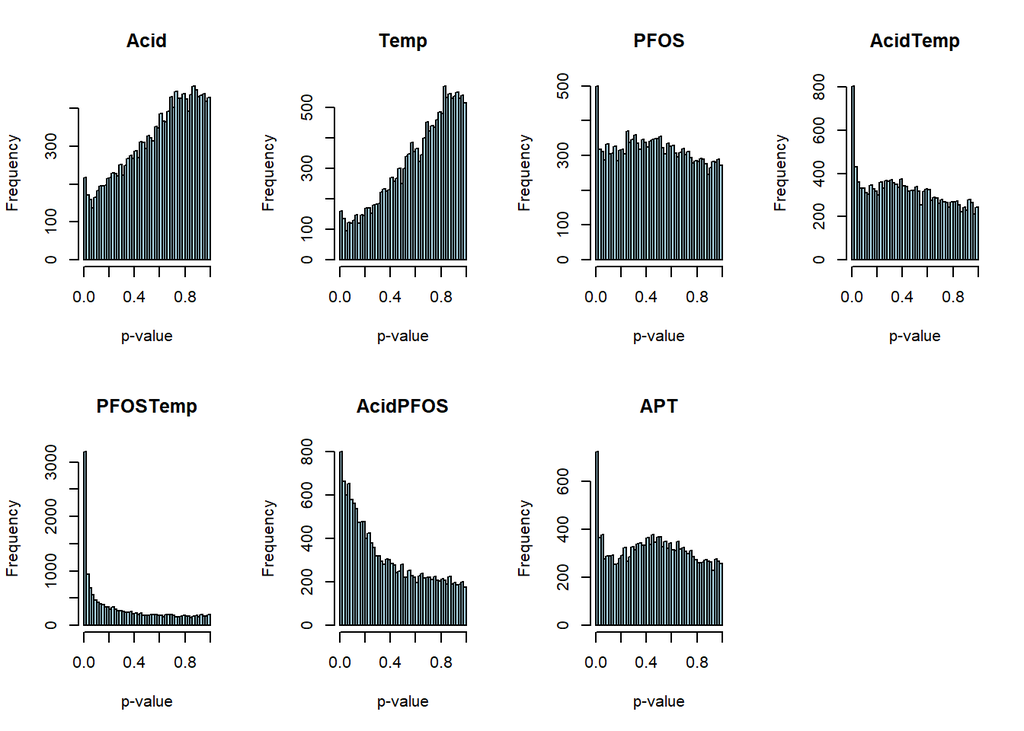

```r
par(mfrow = c(2,4))
for(nm in c("Acid","Temp","PFOS","AcidTemp",
            "PFOSTemp","AcidPFOS","APT")) {
  res <- get(paste0("results_", nm))
  hist(res$pvalue, breaks = 50,
       main = nm, xlab = "p-value",
       col = "lightblue")
}
par(mfrow = c(1,1))
```

Acid and Temp have anti-conservative distributions with p-values enriched near 1 rather than near 0. This suggests that the model cannot reliably detect differential expression for these conditions, either due to insufficient statistical power or high within-group variability relative to between-group differences. All other conditions have good p-value distributions with varying degrees of enrichment near zero, consistent with real differential expression signals.

# Within-group variance assessement

To understand why Acid and Temp show anti-conservative p-value distributions, we examine the within-group biological variability for each condition. DESeq2 estimates a shared dispersion across conditions so if some conditions have higher within-group variance than others, the model have difficulties to distinguish biological signal from noise for those specific comparisons. The within-group variance is calculated using DESeq2-normalised counts, which removes library size differences between samples before computing variance. The median variance across all genes is used as a summary statistic per condition.

```r
norm_counts <- counts(dds_main_f, normalized = TRUE)

# Mean and variance per condition
 for(cond in levels(meta_f_main$condition)) {
     samples <- rownames(meta_f_main)[meta_f_main$condition == cond]
     cat(cond, "— n =", length(samples),
         "| median variance:",
         round(median(apply(norm_counts[, samples], 1, var))), "\n")
}
```

```
## Ctrl — n = 5 | median variance: 1963
## Acid — n = 3 | median variance: 1894
## AcidPFOS — n = 3 | median variance: 566
## AcidTemp — n = 3 | median variance: 567
## APT — n = 3 | median variance: 488
## PFOS — n = 3 | median variance: 666
## PFOSTemp — n = 3 | median variance: 152
## Temp — n = 4 | median variance: 1449
```

Within-group variance differs across conditions. Ctrl, Acid and Temp show higher variance than PFOSTemp, AcidTemp and APT. Several factors contribute to this pattern.

During the developmental exposure phase (0-28 dpf), each condition within each exposure replicate was maintained in a single tank. Fish were subsequently transferred to clean water rearing conditions from 32 dpf onward and maintained until sampling at 15-17 months, during which they were distributed across one to three rearing tanks depending on survival numbers. The transcriptomic analysis therefore reflects the lasting molecular consequences of early developmental exposure rather than acute responses to current tank conditions, which reduces but does not eliminate concerns about tank-level pseudoreplication during the exposure phase.

Conditions with samples from both exposure replicates, including Ctrl, Acid, Temp and PFOS, contain fish from two independent experiments with different breeding groups, different exposure tanks, and approximately one month age difference at sampling. This introduces additional biological variability from genetic background differences and minor environmental variation between replicate experiments. PFOSTemp samples derive exclusively from exposure replicate 3, meaning all fish share the same age, breeding group and exposure tank history. This homogeneity likely contributes to the lower within-group variance observed in PFOSTemp and should be considered when interpreting the consistency of its transcriptional response.

The exposure replicate covariate in the DESeq2 model accounts for systematic mean differences between replicate experiments but does not correct for tank-level effects or differences in biological variability between groups. The practical consequence is reduced statistical power for conditions with higher variance, particularly Acid and Temp. Detected DEGs in these conditions remain statistically valid but real effects may have been missed. GSEA on the full ranked gene list is therefore used as the primary analysis for Acid and Temp as pathway-level analysis is more robust to high individual variability than single-gene testing.

# Volcano plots

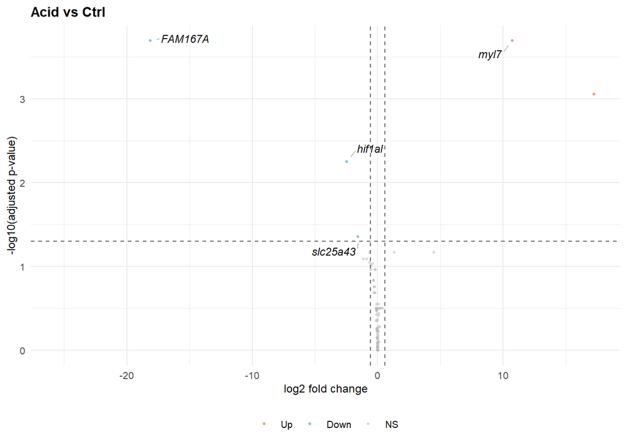

```r
library(ggrepel)

make_volcano <- function(res_df, title,
                         padj_thresh = 0.05,
                         lfc_thresh  = log2(1.5))
                         {
# Assign colour based on the direction of expression change
  res_df$color <- factor(
    ifelse(res_df$direction == "UP",   "Up",
    ifelse(res_df$direction == "DOWN", "Down", "NS")),
    levels = c("Up", "Down", "NS"))

# Label only genes with known names
  labels <- res_df[res_df$direction %in% c("UP","DOWN") &
                       !grepl("^ENSDARG", res_df$gene_name) &
                       !grepl("^si:", res_df$gene_name) &
                       !grepl("^zgc:", res_df$gene_name) &
                       !is.na(res_df$gene_name), ]
# Take only the most significant ones
  top_genes <- head(labels[order(labels$padj), ], 10)

  ggplot(res_df, aes(x = log2FoldChange,
                     y = -log10(padj),
                     color = color)) +
    geom_point(alpha = 0.5, size = 0.7) +
    scale_color_manual(values = c("Up"   = "#D85A30",
                                   "Down" = "#378ADD",
                                   "NS"   = "#BBBBBB")) +
    geom_vline(xintercept = c(-lfc_thresh, lfc_thresh),
               linetype = "dashed", color = "grey40", linewidth = 0.4) +
    geom_hline(yintercept = -log10(padj_thresh),
               linetype = "dashed", color = "grey40", linewidth = 0.4) +
    geom_text_repel(data        = top_genes,
                    aes(label   = gene_name),
                    size        = 3,
                    max.overlaps = Inf,
                    min.segment.length = 0,
                    box.padding = 0.5,
                    point.padding = 0.3,
                    segment.color = "grey50",
                    segment.size = 0.3,
                    color = "black",
                    fontface = "italic") +
    labs(title  = title,
         x      = "log2 fold change",
         y      = "-log10(adjusted p-value)",
         color  = NULL) +
    theme_minimal(base_size = 10) +
    theme(plot.title    = element_text(size = 11, face = "bold"),
          legend.position = "bottom",
          axis.title = element_text(size = 9))
}

# Generate all volcano plots vs Ctrl
p_volc_Acid     <- make_volcano(results_Acid,     "Acid vs Ctrl")
p_volc_Temp     <- make_volcano(results_Temp,     "Temp vs Ctrl")
p_volc_PFOS     <- make_volcano(results_PFOS,     "PFOS vs Ctrl")
p_volc_AcidTemp <- make_volcano(results_AcidTemp, "AcidTemp vs Ctrl")
p_volc_PFOSTemp <- make_volcano(results_PFOSTemp, "PFOSTemp vs Ctrl")
p_volc_AcidPFOS <- make_volcano(results_AcidPFOS, "AcidPFOS vs Ctrl")
p_volc_APT      <- make_volcano(results_APT,      "APT vs Ctrl")

p_volc_AcidTemp <- p_volc_AcidTemp + coord_cartesian(xlim = c(-25, 25), ylim = c(0, 20))
p_volc_PFOSTemp <- p_volc_PFOSTemp + coord_cartesian(xlim = c(-25, 25), ylim = c(0, 20))
p_volc_AcidPFOS <- p_volc_AcidPFOS + coord_cartesian(xlim = c(-25, 25), ylim = c(0, 20))
p_volc_APT      <- p_volc_APT      + coord_cartesian(xlim = c(-25, 25), ylim = c(0, 20))

p_volc_Acid
```

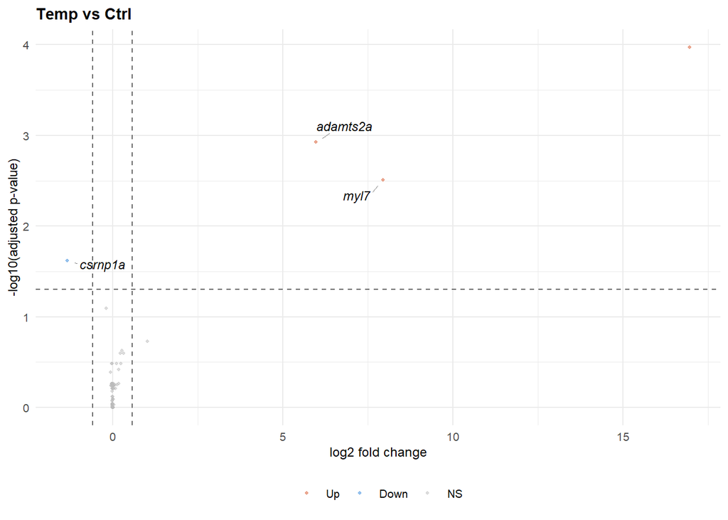

```r
p_volc_Temp
```

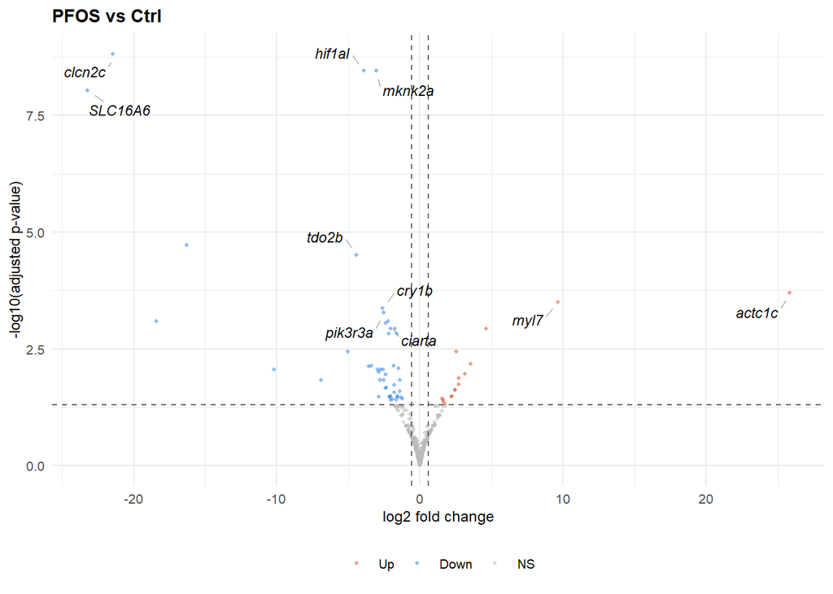

```r
p_volc_PFOS
```

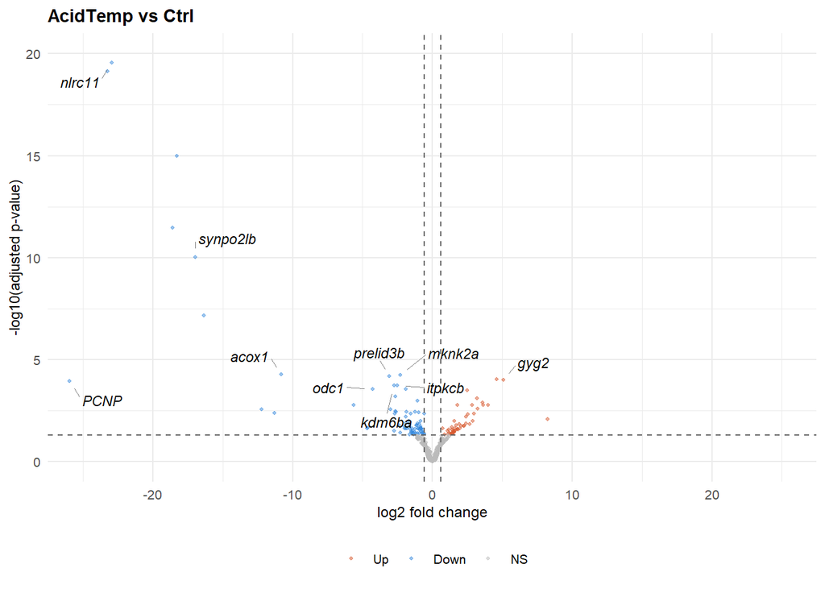

```r
p_volc_AcidTemp
```

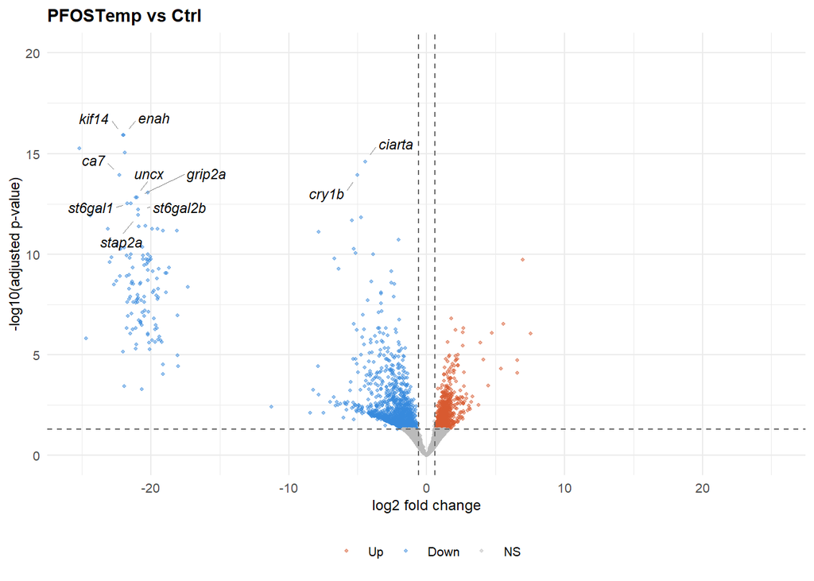

```r
p_volc_PFOSTemp
```

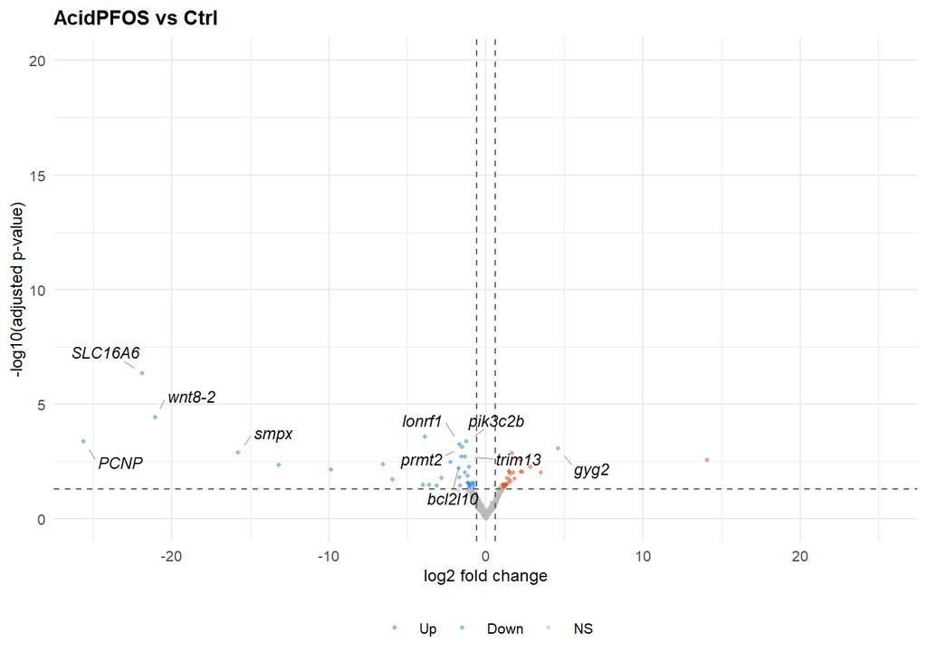

```r
p_volc_AcidPFOS
```

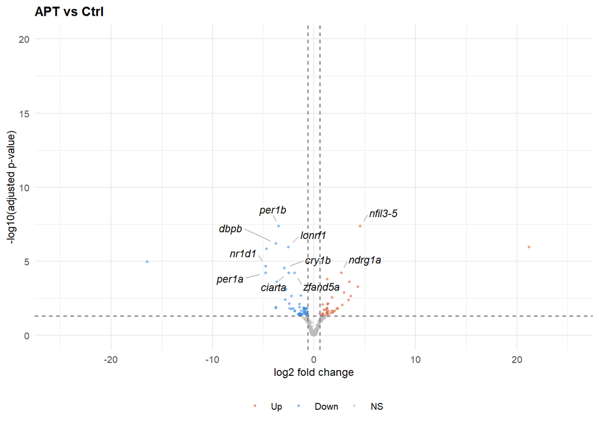

```r
p_volc_APT
```

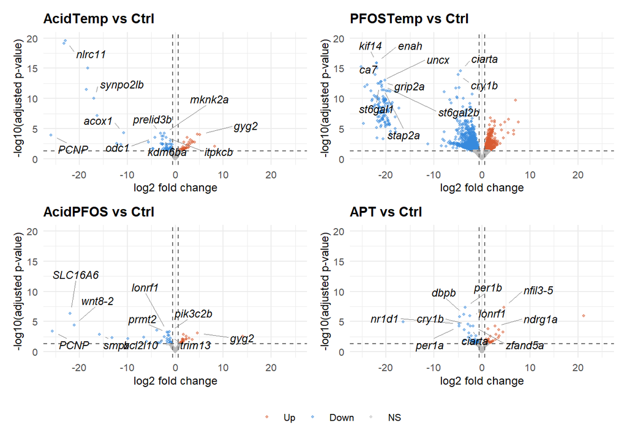

```r
combined_volcano <- (p_volc_AcidTemp + p_volc_PFOSTemp) /
                 (p_volc_AcidPFOS + p_volc_APT) +
  plot_layout(guides = "collect") &
  theme(legend.position = "bottom")
combined_volcano
```

## Stressors interaction analysis

To identify which stressor drives each combination response and to detect emergent, non-additive transcriptomic profiles, the number of differentially expressed genes (DEGs, padj < 0.05, |log2FC| ≥ log2(1.5)) was computed for each combination versus its constituent single stressors, and for APT versus each double stressor. A low DEG count between a combination and one of its singles indicates that the single stressor dominates the combination response, while high DEG counts against both singles indicate an emergent, non-additive signature. The triple stressor APT was compared against each double combination to identify which constituents most strongly modify the APT response.

```r
# Count DEGs for each combination vs its single stressors
# These numbers are used in Table 2 of the manuscript
count_degs <- function(res, padj_cutoff = 0.05, lfc_cutoff = log2(1.5)) {
  df <- as.data.frame(res)
  df <- df[!is.na(df$padj), ]
  up   <- sum(df$padj < padj_cutoff & df$log2FoldChange >=  lfc_cutoff)
  down <- sum(df$padj < padj_cutoff & df$log2FoldChange <= -lfc_cutoff)
  total <- up + down
  c(up = up, down = down, total = total)
}

comparisons <- list(
  list(combo = "AcidTemp", reference = "Acid", res = resLFC_AcidTemp_vs_Acid),
  list(combo = "AcidTemp", reference = "Temp", res = resLFC_AcidTemp_vs_Temp),
  list(combo = "AcidPFOS", reference = "Acid", res = resLFC_AcidPFOS_vs_Acid),
  list(combo = "AcidPFOS", reference = "PFOS", res = resLFC_AcidPFOS_vs_PFOS),
  list(combo = "PFOSTemp", reference = "PFOS", res = resLFC_PFOSTemp_vs_PFOS),
  list(combo = "PFOSTemp", reference = "Temp", res = resLFC_PFOSTemp_vs_Temp),
  list(combo = "APT", reference = "AcidTemp", res = resLFC_APT_vs_AcidTemp),
  list(combo = "APT", reference = "AcidPFOS", res = resLFC_APT_vs_AcidPFOS),
  list(combo = "APT", reference = "PFOSTemp", res = resLFC_APT_vs_PFOSTemp))

table2_data <- do.call(rbind, lapply(comparisons, function(x) {
  counts <- count_degs(x$res)
  data.frame(combo = x$combo, reference = x$reference,
             up = counts["up"], down = counts["down"], total = counts["total"],
             stringsAsFactors = FALSE)
}))

cat("DEG counts (combination vs reference stressor) for Table 2:\n")
```

```
## DEG counts (combination vs reference stressor) for Table 2:
```

```r
print(table2_data)
```

```
##        combo reference  up down total
## up  AcidTemp      Acid  51  149   200
## up1 AcidTemp      Temp   6   24    30
## up2 AcidPFOS      Acid  27   72    99
## up3 AcidPFOS      PFOS  20   25    45
## up4 PFOSTemp      PFOS 287  474   761
## up5 PFOSTemp      Temp 699 1080  1779
## up6      APT  AcidTemp  14    4    18
## up7      APT  AcidPFOS   7    3    10
## up8      APT  PFOSTemp 730  792  1522
```

# Gene Set Enrichment Analysis

```r
library(clusterProfiler)
library(org.Dr.eg.db)

# Function to convert gene IDs to ENTREZ and run gseKEGG
run_kegg_gsea <- function(res, condition_name) {
  set.seed(42)

  df <- as.data.frame(res)
  df$gene_id <- rownames(df)
  df <- df[!is.na(df$log2FoldChange), ]

  # Convert Ensembl to ENTREZ
  entrez_map <- mapIds(
    org.Dr.eg.db,
    keys = df$gene_id,
    column = "ENTREZID",
    keytype = "ENSEMBL",
    multiVals = "first")

  df$entrez <- entrez_map
  df <- df[!is.na(df$entrez), ]
  df <- df[!duplicated(df$entrez), ]

  # Build ranked vector
  ranked <- df$log2FoldChange
  names(ranked) <- df$entrez
  ranked <- sort(ranked, decreasing = TRUE)

  # Run gseKEGG
  res_kegg <- tryCatch(
    gseKEGG(
      geneList = ranked,
      organism = "dre",   # zebrafish
      pvalueCutoff = 1,
      verbose = FALSE),
    error = function(e) NULL)

  # Filter to pathways with q-value < 0.25 (Subramanian threshold)
  if (!is.null(res_kegg) && nrow(res_kegg) > 0) {
    res_kegg@result <- res_kegg@result[res_kegg@result$qvalue < 0.25, ]
  }

  return(res_kegg)
}

# Run on all 7 conditions
kegg_list <- list(
  Acid     = run_kegg_gsea(resLFC_Acid,     "Acid"),
  Temp     = run_kegg_gsea(resLFC_Temp,     "Temp"),
  PFOS     = run_kegg_gsea(resLFC_PFOS,     "PFOS"),
  AcidTemp = run_kegg_gsea(resLFC_AcidTemp, "AcidTemp"),
  AcidPFOS = run_kegg_gsea(resLFC_AcidPFOS, "AcidPFOS"),
  PFOSTemp = run_kegg_gsea(resLFC_PFOSTemp, "PFOSTemp"),
  APT      = run_kegg_gsea(resLFC_APT,      "APT"))
```

```
## Reading KEGG annotation online: "https://rest.kegg.jp/link/dre/pathway"...
```

```
## Reading KEGG annotation online: "https://rest.kegg.jp/list/pathway/dre"...
```

```r
# Summary
cat("KEGG pathways significant per condition:\n")
```

```
## KEGG pathways significant per condition:
```

```r
print(sapply(kegg_list, function(x) {
  if (is.null(x)) return(0)
  nrow(x)
}))
```

```
##     Acid     Temp     PFOS AcidTemp AcidPFOS PFOSTemp      APT
##       15        0       19       17      101       40       70
```

```r
saveRDS(kegg_list, "kegg_list_LOCKED.rds")
cat("\nResults saved to kegg_list_LOCKED.rds\n")
```

```
##
## Results saved to kegg_list_LOCKED.rds
```

```r
# Pool KEGG results from all 7 conditions into one table
kegg_combined <- do.call(rbind, lapply(names(kegg_list), function(nm) {
  g <- kegg_list[[nm]]
  if (is.null(g) || nrow(g) == 0) return(NULL)
  df <- as.data.frame(g)
  df$condition <- nm
  df[, c("ID", "Description", "NES", "p.adjust",
         "setSize", "condition")]
}))

# Set condition order
kegg_combined$condition <- factor(
  kegg_combined$condition,
  levels = c("Acid", "Temp", "PFOS",
             "AcidTemp", "AcidPFOS", "PFOSTemp", "APT"))

cat("Total KEGG entries (pathway × condition):", nrow(kegg_combined), "\n")
```

```
## Total KEGG entries (pathway × condition): 262
```

```r
cat("Unique KEGG pathways:", length(unique(kegg_combined$ID)), "\n")
```

```
## Unique KEGG pathways: 140
```

```r
print(head(kegg_combined))
```

```
##                ID                Description       NES  p.adjust setSize
## dre04260 dre04260 Cardiac muscle contraction  2.415522 0.2189214      82
## dre04520 dre04520          Adherens junction  2.329236 0.2189214     119
## dre00030 dre00030  Pentose phosphate pathway  2.082490 0.2189214      28
## dre04510 dre04510             Focal adhesion  2.067782 0.2189214     196
## dre04216 dre04216                Ferroptosis -2.009253 0.2189214      48
## dre00860 dre00860       Porphyrin metabolism -1.999300 0.2189214      53
##          condition
## dre04260      Acid
## dre04520      Acid
## dre00030      Acid
## dre04510      Acid
## dre04216      Acid
## dre00860      Acid
```

```r
library(KEGGREST)
```

```r
# Fetch official KEGG pathway hierarchy
brite <- keggGet("br:br08901")[[1]]

# Parse the hierarchy: A = top category, B = subcategory, C = pathway
# Lines look like:
# A<b>Metabolism</b>
# B  <b>Global and overview maps</b>
# C    01100  Metabolic pathways
lines <- strsplit(brite, "\n")[[1]]

# Build pathway → category mapping from the parsed hierarchy
build_kegg_map <- function(lines) {
  current_A <- ""
  current_B <- ""
  pathway_map <- list()

  for (line in lines) {
    if (startsWith(line, "A")) {
      current_A <- gsub("^A|<[^>]+>", "", line) |> trimws()
    } else if (startsWith(line, "B")) {
      current_B <- gsub("^B\\s*|<[^>]+>", "", line) |> trimws()
    } else if (startsWith(line, "C")) {
      # Extract pathway ID and name
      m <- regmatches(line, regexec("^C\\s+(\\d{5})\\s+(.+)$", line))[[1]]
      if (length(m) >= 3) {
        pathway_id <- m[2]
        pathway_map[[pathway_id]] <- list(
          A = current_A,
          B = current_B,
          name = m[3])
      }
    }
  }
  pathway_map
}

kegg_hierarchy <- build_kegg_map(lines)
cat("Total KEGG pathways in BRITE hierarchy:", length(kegg_hierarchy), "\n")
```

```
## Total KEGG pathways in BRITE hierarchy: 587
```

```r
# Build a tidy lookup data frame
kegg_lookup <- do.call(rbind, lapply(names(kegg_hierarchy), function(id) {
  data.frame(
    pathway_id = id,
    category_A = kegg_hierarchy[[id]]$A,
    category_B = kegg_hierarchy[[id]]$B,
    pathway_name = kegg_hierarchy[[id]]$name,
    stringsAsFactors = FALSE)
}))

# Now apply to your kegg_combined table
# Strip "dre" prefix to match
kegg_combined$pathway_id <- gsub("dre", "", kegg_combined$ID)
kegg_combined$category_A <- kegg_lookup$category_A[
  match(kegg_combined$pathway_id, kegg_lookup$pathway_id)]
kegg_combined$category_B <- kegg_lookup$category_B[
  match(kegg_combined$pathway_id, kegg_lookup$pathway_id)]

cat("\nPathways per top-level category (A):\n")
```

```
##
## Pathways per top-level category (A):
```

```r
print(table(kegg_combined$category_A[!duplicated(kegg_combined$ID)]))
```

```
##
##                   Cellular Processes Environmental Information Processing
##                                   17                                   16
##       Genetic Information Processing                       Human Diseases
##                                   24                                    3
##                           Metabolism                   Organismal Systems
##                                   68                                   12
```

```r
cat("\nPathways per subcategory (B):\n")
```

```
##
## Pathways per subcategory (B):
```

```r
print(table(kegg_combined$category_B[!duplicated(kegg_combined$ID)]))
```

```
##
##                     Amino acid metabolism
##                                        10
##                   Carbohydrate metabolism
##                                        13
##                     Cell growth and death
##                                         5
##                             Cell motility
##                                         3
##           Cellular community - eukaryotes
##                                         3
##                                Chromosome
##                                         2
##                        Circulatory system
##                                         1
##              Development and regeneration
##                                         1
##                          Digestive system
##                                         1
##                          Endocrine system
##                                         4
##                         Energy metabolism
##                                         3
##          Folding, sorting and degradation
##                                         6
##                  Global and overview maps
##                                         7
##        Glycan biosynthesis and metabolism
##                                         9
##                             Immune system
##                                         4
##             Infectious disease: bacterial
##                                         2
##                 Infectious disease: viral
##                                         1
##         Information processing in viruses
##                                         3
##                          Lipid metabolism
##                                        10
##      Metabolism of cofactors and vitamins
```

[output cut: 8 more lines]

```
##                                         6
##                            Sensory system
##                                         1
##                       Signal transduction
##                                         8
##       Signaling molecules and interaction
##                                         8
##                             Transcription
##                                         3
##                               Translation
##                                         4
##                  Transport and catabolism
##                                         6
## Xenobiotics biodegradation and metabolism
##                                         3
```

```r
cat("\nUnmapped pathways (should be empty):\n")
```

```
##
## Unmapped pathways (should be empty):
```

```r
unique(kegg_combined[is.na(kegg_combined$category_A), c("ID", "Description")])
```

```
## [1] ID          Description
## <0 rows> (or 0-length row.names)
```

```r
head(kegg_combined[, c("Description", "category_A", "category_B", "NES", "condition")])
```

```
##                         Description         category_A
## dre04260 Cardiac muscle contraction Organismal Systems
## dre04520          Adherens junction Cellular Processes
## dre00030  Pentose phosphate pathway         Metabolism
## dre04510             Focal adhesion Cellular Processes
## dre04216                Ferroptosis Cellular Processes
## dre00860       Porphyrin metabolism         Metabolism
##                                    category_B       NES condition
## dre04260                   Circulatory system  2.415522      Acid
## dre04520      Cellular community - eukaryotes  2.329236      Acid
## dre00030              Carbohydrate metabolism  2.082490      Acid
## dre04510      Cellular community - eukaryotes  2.067782      Acid
## dre04216                Cell growth and death -2.009253      Acid
## dre00860 Metabolism of cofactors and vitamins -1.999300      Acid
```

```r
table(kegg_combined$category_B[!duplicated(kegg_combined$ID)])
```

```
##
##                     Amino acid metabolism
##                                        10
##                   Carbohydrate metabolism
##                                        13
##                     Cell growth and death
##                                         5
##                             Cell motility
##                                         3
##           Cellular community - eukaryotes
##                                         3
##                                Chromosome
##                                         2
##                        Circulatory system
##                                         1
##              Development and regeneration
##                                         1
##                          Digestive system
##                                         1
##                          Endocrine system
##                                         4
##                         Energy metabolism
##                                         3
##          Folding, sorting and degradation
##                                         6
##                  Global and overview maps
##                                         7
##        Glycan biosynthesis and metabolism
##                                         9
##                             Immune system
##                                         4
##             Infectious disease: bacterial
##                                         2
##                 Infectious disease: viral
##                                         1
##         Information processing in viruses
##                                         3
##                          Lipid metabolism
##                                        10
##      Metabolism of cofactors and vitamins
```

[output cut: 8 more lines]

```
##                                         6
##                            Sensory system
##                                         1
##                       Signal transduction
##                                         8
##       Signaling molecules and interaction
##                                         8
##                             Transcription
##                                         3
##                               Translation
##                                         4
##                  Transport and catabolism
##                                         6
## Xenobiotics biodegradation and metabolism
##                                         3
```

```r
# Build KEGG pathway lists per condition
kegg_pathway_lists <- lapply(kegg_list, function(g) {
  if (is.null(g) || nrow(g) == 0) return(character(0))
  as.data.frame(g)$Description
})

library(ComplexUpset)
```

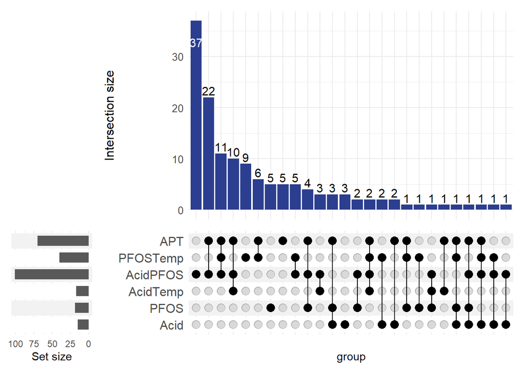

```r
# Build UpSet matrix
all_kegg_pathways <- unique(unlist(kegg_pathway_lists))
kegg_upset_df <- data.frame(pathway = all_kegg_pathways,
                            stringsAsFactors = FALSE)
for (cond in names(kegg_pathway_lists)) {
  kegg_upset_df[[cond]] <- kegg_upset_df$pathway %in% kegg_pathway_lists[[cond]]
}

conditions_with_data <- names(kegg_pathway_lists)[
  sapply(kegg_pathway_lists, length) > 0]

p_panelC <- ComplexUpset::upset(
  kegg_upset_df,
  intersect = conditions_with_data,
  min_size = 1,
  width_ratio = 0.2,
  sort_sets = FALSE,
  sort_intersections_by = "cardinality",
  base_annotations = list(
    'Intersection size' = intersection_size(
  mapping = aes(fill = 'bars'),
  text = list(size = 4)) +
  scale_fill_manual(values = c('bars' = '#2C3E8F'), guide = 'none') +
  theme(axis.title = element_text(size = 12),
        axis.text  = element_text(size = 10))),
  themes = upset_modify_themes(
    list(
      'intersections_matrix' = theme(
        axis.text.y = element_text(size = 12)))))
p_panelC
```

```r
# Filter out "Global and overview maps" (umbrella pathways with too much overlap)
kegg_for_plot <- kegg_combined %>%
  filter(category_B != "Global and overview maps")

cat("Pathways for Panel B:", length(unique(kegg_for_plot$ID)), "\n")
```

```
## Pathways for Panel B: 133
```

```r
cat("Categories:", length(unique(kegg_for_plot$category_B)), "\n")
```

```
## Categories: 30
```

```r
top_pathways <- kegg_for_plot %>%
  group_by(Description) %>%
  summarise(max_abs_NES = max(abs(NES)), .groups = "drop") %>%
  arrange(desc(max_abs_NES)) %>%
  slice_head(n = 30) %>%
  pull(Description)

kegg_for_plot <- kegg_for_plot %>%
  filter(Description %in% top_pathways)

cat("After filtering: ", length(unique(kegg_for_plot$ID)), " pathways across ",
    length(unique(kegg_for_plot$category_B)), " categories\n", sep = "")
```

```
## After filtering: 30 pathways across 16 categories
```

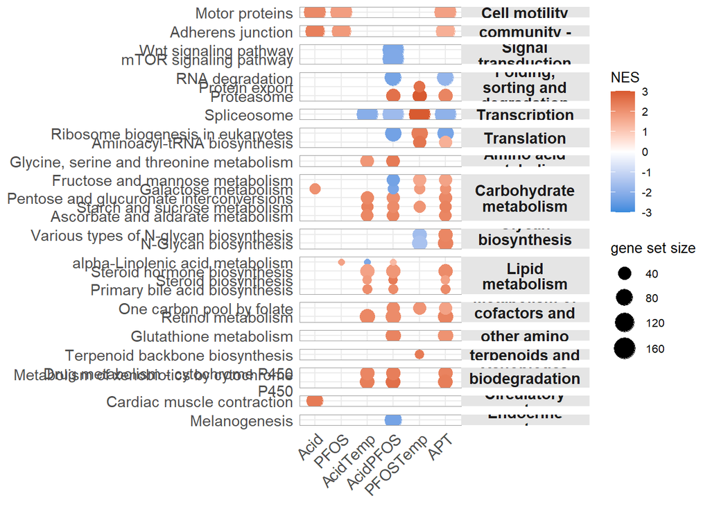

```r
# Order categories: Metabolism first, then Genetic Info, then Cellular, etc.
category_order <- kegg_for_plot %>%
  dplyr::select(category_A, category_B) %>%
  distinct() %>%
  arrange(category_A, category_B) %>%
  pull(category_B)

kegg_for_plot$category_B <- factor(kegg_for_plot$category_B,
                                     levels = category_order)

# Wrap category names to fit vertical strips (max ~14 chars per line)
kegg_for_plot$category_B_wrap <- stringr::str_wrap(
  as.character(kegg_for_plot$category_B), width = 14)

kegg_for_plot$category_B_wrap <- factor(
  kegg_for_plot$category_B_wrap,
  levels = stringr::str_wrap(category_order, width = 14))

# Order pathways within each category by mean NES
pathway_order <- kegg_for_plot %>%
  group_by(category_B, Description) %>%
  summarise(mean_NES = mean(NES), .groups = "drop") %>%
  arrange(category_B, desc(mean_NES)) %>%
  pull(Description)

kegg_for_plot$Description <- factor(kegg_for_plot$Description,
                                      levels = unique(pathway_order))

# Wrap long pathway names
kegg_for_plot$Description_wrap <- stringr::str_wrap(
  as.character(kegg_for_plot$Description), width = 40)
kegg_for_plot$Description_wrap <- factor(
  kegg_for_plot$Description_wrap,
  levels = stringr::str_wrap(unique(pathway_order), width = 40))

# Build the plot
p_panelB <- ggplot(kegg_for_plot,
                    aes(x = condition, y = Description_wrap,
                        size = setSize, color = NES)) +
  geom_point() +
  facet_grid(category_B_wrap ~ ., scales = "free_y", space = "free_y") +
  scale_color_gradient2(
    low = "#378ADD", mid = "white", high = "#D85A30",
    midpoint = 0,
    name = "NES",
    limits = c(-3, 3),
    oob = scales::squish) +
  scale_size_continuous(name = "gene set size", range = c(2, 7)) +
  labs(x = NULL, y = NULL) +
  theme_minimal(base_size = 10) +
  theme(
    axis.text.x = element_text(angle = 45, hjust = 1, size = 11),
    axis.text.y = element_text(size = 11),
    strip.text.y = element_text(angle = 0, face = "bold", size = 11,
                              lineheight = 0.85),
    strip.placement = "outside",
    strip.background = element_rect(fill = "grey90", color = NA),
    panel.spacing.y = unit(0.4, "lines"),
    panel.border = element_rect(color = "grey60", fill = NA, linewidth = 0.3),
    legend.position = "right")

p_panelB
```

```r
ggsave("Figure4_PanelB_KEGG.pdf", p_panelB,
       width = 12, height = 14, units = "in", dpi = 300)

ggsave("Figure4_PanelB_KEGG.png", p_panelB,
       width = 12, height = 14, units = "in", dpi = 600)
```

```r
left_column <- plot_grid(
  combined_volcano, p_panelC,
  ncol = 1,
  rel_heights = c(1, 1),
  labels = c("A", "B"),
  label_size = 14)
final_figure <- plot_grid(
  left_column, p_panelB,
  ncol = 2,
  rel_widths = c(1, 1.3),
  labels = c("", "C"),
  label_size = 14)

ggsave("Figure4_transcriptomics.png",
       final_figure,
       width = 14, height = 15, units = "in", dpi = 600)

ggsave("Figure4_transcriptomics.pdf",
       final_figure,
       width = 14, height = 12, units = "in", dpi = 300)
```

# Supplementary analysis — Gene Ontology biological process enrichment

GO biological process enrichment was performed in parallel with KEGG analysis to provide complementary functional insight. Results are presented as supplementary material since KEGG analysis was used as the primary functional annotation framework for cross-omics integration with the metabolomic and lipidomic data.

```r
OrgDb   <- org.Dr.eg.db
keytype <- "ENSEMBL"
```

```r
run_GSEA <- function(res_df, condition_name,
                     OrgDb   = org.Dr.eg.db,
                     ont     = "BP",
                     minSize = 15,
                     maxSize = 500) {

  # Remove genes with NA fold change, p-values or gene ID
  res_clean <- res_df[!is.na(res_df$log2FoldChange) &
                      !is.na(res_df$pvalue) &
                      !is.na(res_df$gene_id), ]

  # Build ranked list using sign(LFC) * -log10(pvalue)
  res_clean$rank <- sign(res_clean$log2FoldChange) *
                    -log10(res_clean$pvalue)

  gene_list <- res_clean$rank
  names(gene_list) <- res_clean$gene_id
  gene_list <- sort(gene_list, decreasing = TRUE)

  # Remove duplicates (keep highest rank)
  gene_list <- gene_list[!duplicated(names(gene_list))]

  # Run GSEA on GO (Biological Process) terms
  gsea_res <- gseGO(
    geneList     = gene_list,
    OrgDb        = OrgDb,
    keyType      = keytype,
    ont          = ont,
    minGSSize    = minSize,
    maxGSSize    = maxSize,
    pvalueCutoff = 0.05,
    pAdjustMethod = "BH",
    verbose      = FALSE,
    seed         = 42   # for reproducibility
  )

  # Simplify to remove redundant GO terms
  gsea_simplified <- simplify(gsea_res,
                               cutoff    = 0.7,
                               by        = "p.adjust",
                               select_fun = min)

  cat("\n===", condition_name, "===\n")
  cat("Significant pathways (raw):", nrow(gsea_res), "\n")
  cat("After simplification:", nrow(gsea_simplified), "\n")

  return(gsea_simplified)
}
```

```r
# Run GSEA for all conditions vs Ctrl
gsea_Acid     <- run_GSEA(results_Acid,     "Acid")
```

```
##
## === Acid ===
## Significant pathways (raw): 89
## After simplification: 41
```

```r
gsea_Temp     <- run_GSEA(results_Temp,     "Temp")
```

```
##
## === Temp ===
## Significant pathways (raw): 66
## After simplification: 34
```

```r
gsea_PFOS     <- run_GSEA(results_PFOS,     "PFOS")
```

```
##
## === PFOS ===
## Significant pathways (raw): 141
## After simplification: 77
```

```r
gsea_AcidTemp <- run_GSEA(results_AcidTemp, "AcidTemp")
```

```
##
## === AcidTemp ===
## Significant pathways (raw): 102
## After simplification: 50
```

```r
gsea_PFOSTemp <- run_GSEA(results_PFOSTemp, "PFOSTemp")
```

```
##
## === PFOSTemp ===
## Significant pathways (raw): 172
## After simplification: 70
```

```r
gsea_AcidPFOS <- run_GSEA(results_AcidPFOS, "AcidPFOS")
```

```
##
## === AcidPFOS ===
## Significant pathways (raw): 344
## After simplification: 123
```

```r
gsea_APT      <- run_GSEA(results_APT,      "APT")
```

```
##
## === APT ===
## Significant pathways (raw): 132
## After simplification: 58
```

The number of significant pathways varied substantially across conditions, with AcidPFOS showing the broadest pathway-level response (123 pathways) despite relatively few DEGs (74), illustrating that GSEA and DEG analysis are complementary and GSEA detects coordinated shifts across gene sets that may not reach significance at the individual gene level. Acid and Temp showed 41 and 34 significant pathways respectively despite almost no individual DEGs.

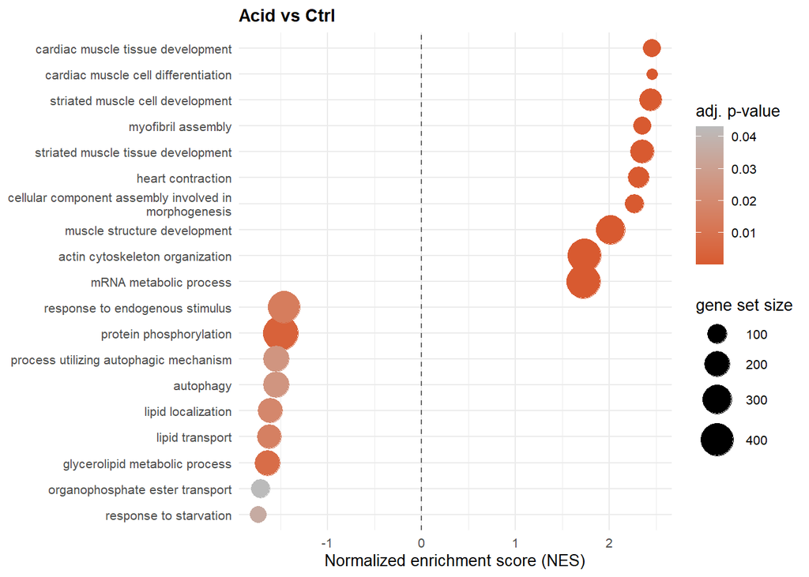

```r
# Create the bubble plot function with x axis = NES (normalized enrichment score) and y axis = pathway name. Size = number of genes in pathway that contributed and color =  adjusted p-value.
make_bubble <- function(gsea_obj, title, n_top = 20) {

  if (is.null(gsea_obj) || nrow(gsea_obj) == 0) {
    message("No significant pathways for: ", title)
    return(NULL)
  }

  df <- as.data.frame(gsea_obj)

  # Select top n by p.adjust, split up/down evenly if possible
  df_up   <- df[df$NES > 0, ]
  df_down <- df[df$NES < 0, ]

  n_up   <- min(nrow(df_up),   ceiling(n_top / 2))
  n_down <- min(nrow(df_down), ceiling(n_top / 2))

  df_up   <- head(df_up[order(df_up$p.adjust), ],   n_up)
  df_down <- head(df_down[order(df_down$p.adjust), ], n_down)
  df_plot <- rbind(df_up, df_down)

  # Wrap long pathway names
  df_plot$Description <- stringr::str_wrap(df_plot$Description,
                                            width = 50)

  # Order by NES for readability
  df_plot$Description <- factor(df_plot$Description,
                                 levels = df_plot$Description[
                                   order(df_plot$NES)])

  ggplot(df_plot, aes(x     = NES,
                       y     = Description,
                       size  = setSize,
                       color = p.adjust)) +
    geom_point() +
    scale_color_gradient(low  = "#D85A30",
                          high = "#BBBBBB",
                          name = "adj. p-value") +
    scale_size_continuous(name = "gene set size",
                           range = c(3, 10)) +
    geom_vline(xintercept = 0, linetype = "dashed",
               color = "grey40", linewidth = 0.4) +
    labs(title = title,
         x     = "Normalized enrichment score (NES)",
         y     = NULL) +
    theme_minimal(base_size = 10) +
    theme(plot.title    = element_text(size = 11, face = "bold"),
          axis.text.y   = element_text(size = 8),
          legend.position = "right")
}

# Generate bubble plots
p_bubble_Acid     <- make_bubble(gsea_Acid,     "Acid vs Ctrl")
p_bubble_Temp     <- make_bubble(gsea_Temp,     "Temp vs Ctrl")
p_bubble_PFOS     <- make_bubble(gsea_PFOS,     "PFOS vs Ctrl")
p_bubble_AcidTemp <- make_bubble(gsea_AcidTemp, "AcidTemp vs Ctrl")
p_bubble_PFOSTemp <- make_bubble(gsea_PFOSTemp, "PFOSTemp vs Ctrl")
p_bubble_AcidPFOS <- make_bubble(gsea_AcidPFOS, "AcidPFOS vs Ctrl")
p_bubble_APT      <- make_bubble(gsea_APT,      "APT vs Ctrl")

# Print each plot individually
p_bubble_Acid
```

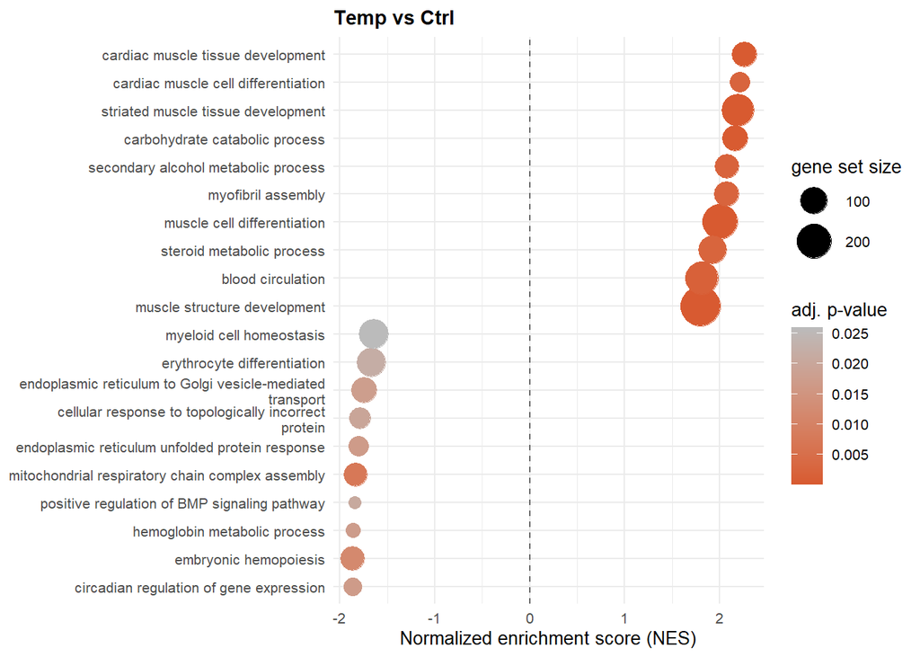

```r
p_bubble_Temp
```

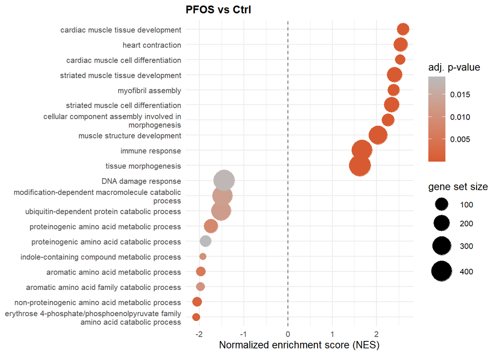

```r
p_bubble_PFOS
```

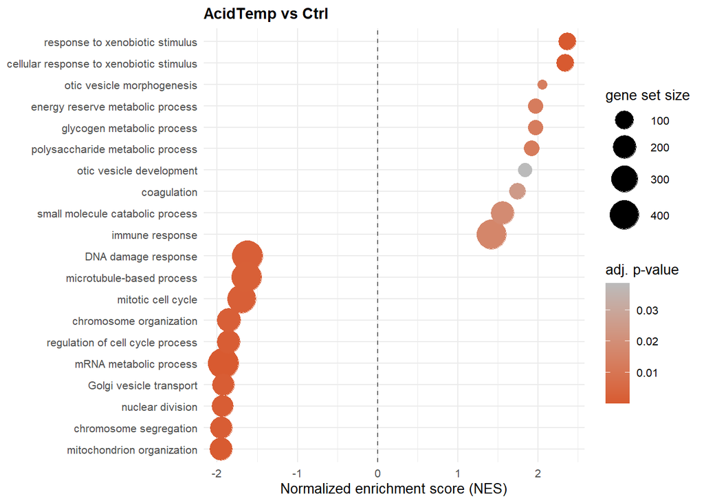

```r
p_bubble_AcidTemp
```

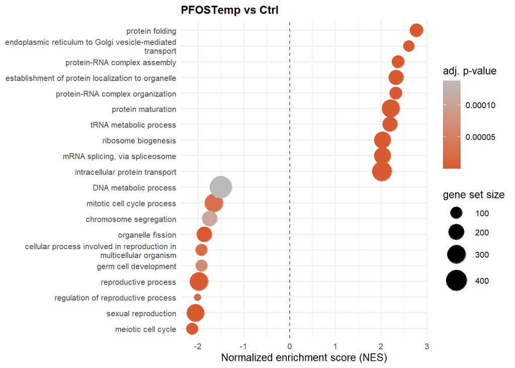

```r
p_bubble_PFOSTemp
```

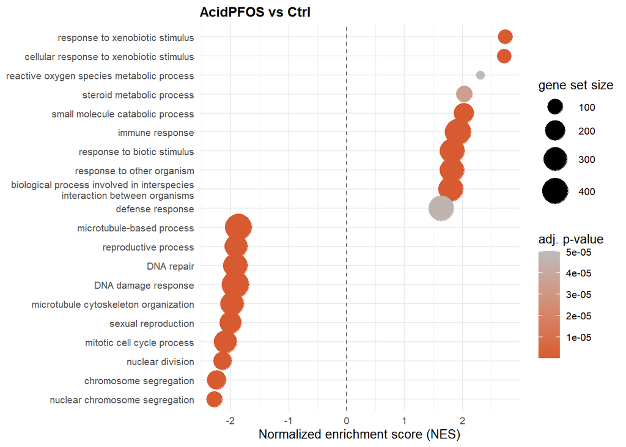

```r
p_bubble_AcidPFOS
```

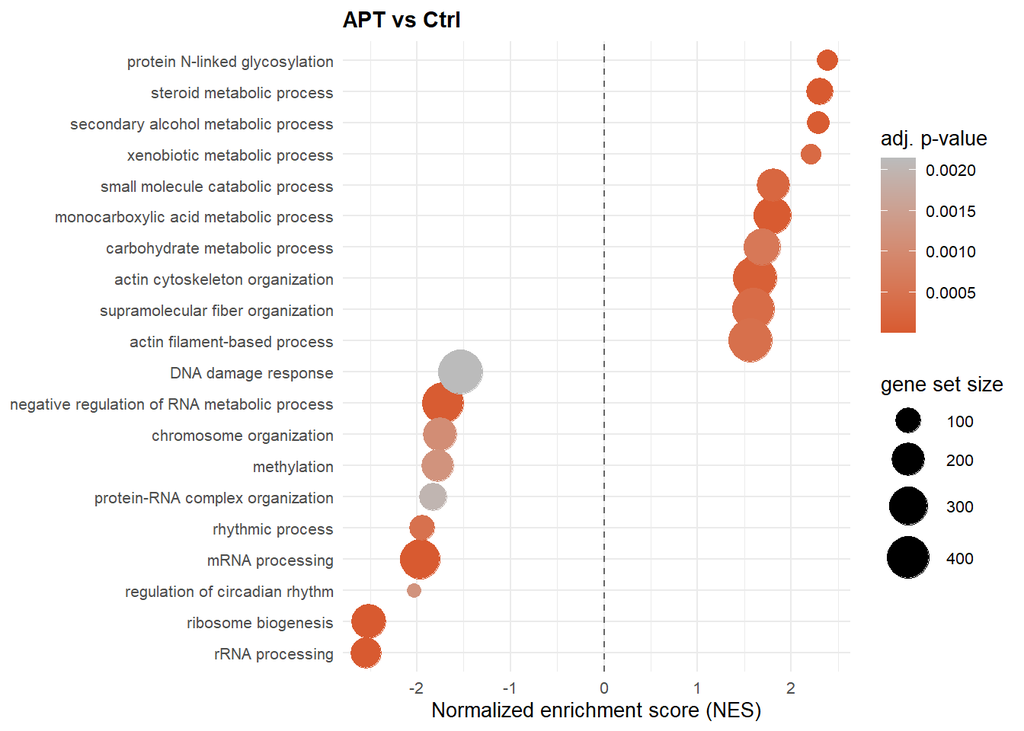

```r
p_bubble_APT
```

Temperature exposure suppresses mitochondrial respiratory chain assembly and circadian regulation of gene expression, suggesting that thermal stress disrupts both energy production and temporal organisation of hepatic metabolism.

AcidTemp activates xenobiotic stimulus response = chemical stress detection pathway. Also activates glycogen and energy reserve metabolism, while strongly suppressing cell cycle progression, DNA damage response, and mitochondrial organisation. This broad suppression of proliferative and repair processes suggests that combined acid and temperature stress induces a state of metabolic arrest in the liver.

AcidPFOS activates xenobiotic and immune response pathways similarly to AcidTemp, and strongly suppresses cell cycle, DNA repair, and chromosome segregation with very low adjusted p-values. ¨

APT activates xenobiotic metabolism, glycosylation, and carbohydrate metabolism, while suppressing ribosome biogenesis, rRNA processing, and circadian rhythm regulation. The suppression of ribosome biogenesis in APT is in direct contrast to its activation in PFOSTemp –> adding acid to the PFOS-temperature combination abolishes the proteostatic adaptive response. The suppression of circadian rhythm regulation in APT is consistent with the circadian clock genes identified as significant DEGs in this condition, suggesting that triple stressor exposure specifically disrupts hepatic temporal organisation.

```r
# Summary table of GSEA results across all conditions
gsea_list <- list(
  Acid     = gsea_Acid,
  Temp     = gsea_Temp,
  PFOS     = gsea_PFOS,
  AcidTemp = gsea_AcidTemp,
  PFOSTemp = gsea_PFOSTemp,
  AcidPFOS = gsea_AcidPFOS,
  APT      = gsea_APT
)

gsea_summary <- sapply(gsea_list, function(g) {
  if (is.null(g) || nrow(g) == 0) return(c(Activated=0, Suppressed=0, Total=0))
  df <- as.data.frame(g)
  c(Activated  = sum(df$NES > 0),
    Suppressed = sum(df$NES < 0),
    Total      = nrow(df))
})

cat("GSEA pathway summary (after simplification, padj < 0.05):\n")
```

```
## GSEA pathway summary (after simplification, padj < 0.05):
```

```r
print(t(gsea_summary))
```

```
##          Activated Suppressed Total
## Acid            32          9    41
## Temp            24         10    34
## PFOS            45         32    77
## AcidTemp        11         39    50
## PFOSTemp        41         29    70
## AcidPFOS        54         69   123
## APT             31         27    58
```

# Shared pathways analysis

To visualise pathway enrichment across all conditions simultaneously, GSEA results from the seven exposure conditions were pooled into a single long-format table. GO identifiers were retained alongside pathway descriptions to enable semantic similarity analysis in the next step.

```r
# Pool GSEA results from all 7 conditions into one table.
# Each row = one pathway in one condition.
# The ID column (GO:xxxxxx) is needed for rrvgo clustering later.
gsea_combined <- do.call(rbind, lapply(names(gsea_list), function(nm) {
  g <- gsea_list[[nm]]
  if (is.null(g) || nrow(g) == 0) return(NULL)
  df <- as.data.frame(g)
  df$condition <- nm
  df[, c("ID", "Description", "NES", "p.adjust",
         "setSize", "condition")]
}))

# Set a logical order for conditions (single → double → triple stressors)
gsea_combined$condition <- factor(
  gsea_combined$condition,
  levels = c("Acid", "Temp", "PFOS",
             "AcidTemp", "AcidPFOS", "PFOSTemp",
             "APT"))

# Quick check
cat("Total GSEA entries (pathway × condition):", nrow(gsea_combined), "\n")
```

```
## Total GSEA entries (pathway × condition): 453
```

```r
cat("Unique pathways:", length(unique(gsea_combined$ID)), "\n")
```

```
## Unique pathways: 305
```

```r
head(gsea_combined)
```

```
##                    ID                         Description      NES     p.adjust
## GO:0048738 GO:0048738   cardiac muscle tissue development 2.454964 2.098000e-08
## GO:0055002 GO:0055002    striated muscle cell development 2.440726 2.098000e-08
## GO:0014706 GO:0014706  striated muscle tissue development 2.347376 2.098000e-08
## GO:0060047 GO:0060047                   heart contraction 2.309161 2.098000e-08
## GO:0061061 GO:0061061        muscle structure development 2.009421 2.246982e-08
## GO:0055007 GO:0055007 cardiac muscle cell differentiation 2.450077 7.058093e-08
##            setSize condition
## GO:0048738      78      Acid
## GO:0055002     139      Acid
## GO:0014706     166      Acid
## GO:0060047     128      Acid
## GO:0061061     297      Acid
## GO:0055007      41      Acid
```

To group related GO terms by biological theme, the rrvgo package was used to compute semantic similarity between all GO biological process terms identified in any condition, and to cluster them into parent terms based on ontology distance (threshold = 0.7). The resulting rrvgo parent terms were then manually merged into broader biological themes to facilitate visualisation and interpretation.

```r
# Unique GO IDs across all conditions (rrvgo works on a unique set)
unique_ids <- unique(gsea_combined$ID)

# Build similarity matrix: pairwise semantic similarity between GO terms using the zebrafish ontology
simMatrix <- calculateSimMatrix(
  unique_ids,
  orgdb = "org.Dr.eg.db",
  ont   = "BP",
  method = "Rel")
```

```
## preparing gene to GO mapping data...
```

```
## preparing IC data...
```

```r
# Score each GO term by its lowest p.adjust across all conditions so that the most significant term per cluster becomes the representative one
term_scores <- gsea_combined %>%
  group_by(ID) %>%
  summarise(best_padj = min(p.adjust), .groups = "drop")

scores <- setNames(-log10(term_scores$best_padj), term_scores$ID)

# Reduce to cluster representatives (parent terms) at similarity threshold 0.7
reducedTerms <- reduceSimMatrix(
  simMatrix,
  scores,
  threshold = 0.7,
  orgdb = "org.Dr.eg.db")
reducedTerms <- as.data.frame(reducedTerms)

cat("Number of rrvgo clusters:", length(unique(reducedTerms$parentTerm)), "\n")
```

```
## Number of rrvgo clusters: 61
```

```r
print(dplyr::count(reducedTerms, parentTerm, sort = TRUE))
```

```
##                                                                   parentTerm  n
## 1                                                        ribosome biogenesis 21
## 2                                                                 DNA repair 12
## 3                                                            protein folding 12
## 4                                                     tRNA metabolic process 11
## 5                                          cardiac muscle tissue development 10
## 6                                                 mitotic cell cycle process 10
## 7                                            response to xenobiotic stimulus 10
## 8                                           small molecule catabolic process 10
## 9                                                      ATP metabolic process  9
## 10                                                            mRNA transport  9
## 11                                          protein-RNA complex organization  9
## 12                                                 steroid metabolic process  9
## 13                                                           immune response  8
## 14                                              muscle structure development  8
```

[output cut: 47 more lines]

```r
openxlsx::write.xlsx(
  dplyr::count(reducedTerms, parentTerm, sort = TRUE),
  file = "rrvgo_parent_terms.xlsx"
)
```

```r
# Step 1: Map every GSEA result to its rrvgo parent cluster

all_with_parent <- gsea_combined %>%
  left_join(reducedTerms[, c("go", "parentTerm")],
            by = c("ID" = "go")) %>%
  filter(!is.na(parentTerm))

# Step 2: For each (condition × parent), keep only the most significant child term. This is the cluster-level signal.
cluster_per_condition <- all_with_parent %>%
  group_by(condition, parentTerm) %>%
  slice_min(p.adjust, n = 1, with_ties = FALSE) %>%
  ungroup()

# Step 3: select the 4 parent clusters with strongest signal(lowest p.adjust), regardless of direction (up or down)
top_parents <- cluster_per_condition %>%
  group_by(condition) %>%
  slice_min(p.adjust, n = 4) %>%   # top 4 strongest per condition
  ungroup() %>%
  pull(parentTerm) %>%
  unique()

cat("Number of parent clusters selected for Panel B:",
    length(top_parents), "\n")
```

```
## Number of parent clusters selected for Panel B: 18
```

```r
print(sort(top_parents))
```

```
##  [1] "carbohydrate catabolic process"
##  [2] "cardiac muscle tissue development"
##  [3] "DNA repair"
##  [4] "endoplasmic reticulum to Golgi vesicle-mediated transport"
##  [5] "heart contraction"
##  [6] "immune response"
##  [7] "intracellular protein transport"
##  [8] "microtubule cytoskeleton organization"
##  [9] "mitotic cell cycle process"
## [10] "muscle structure development"
## [11] "protein-RNA complex organization"
## [12] "protein folding"
## [13] "protein N-linked glycosylation"
## [14] "reproductive process"
## [15] "response to xenobiotic stimulus"
## [16] "ribosome biogenesis"
## [17] "steroid metabolic process"
## [18] "tRNA metabolic process"
```

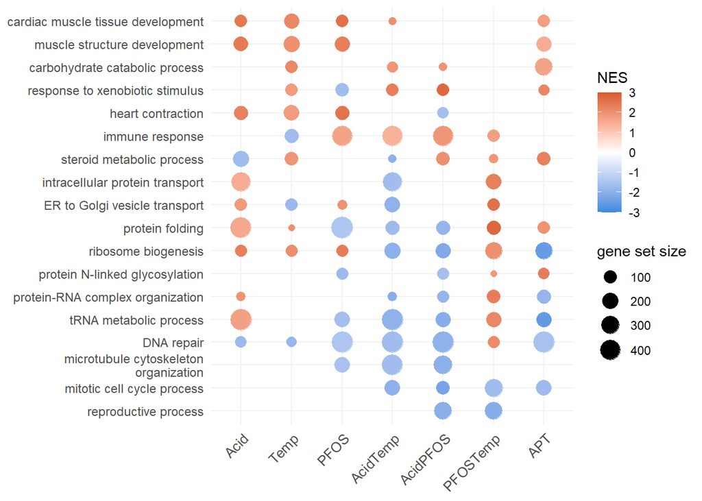

```r
panelB_data <- cluster_per_condition %>%
  filter(parentTerm %in% top_parents)

#rename too long names
panelB_data$parentTerm[panelB_data$parentTerm ==
  "endoplasmic reticulum to Golgi vesicle-mediated transport"] <-
  "ER to Golgi vesicle transport"

# Order parents by mean NES (suppressed bottom, activated top)
parent_order <- panelB_data %>%
  group_by(parentTerm) %>%
  summarise(mean_NES = mean(NES), .groups = "drop") %>%
  arrange(mean_NES) %>%
  pull(parentTerm)

panelB_data$parentTerm <- factor(panelB_data$parentTerm,
                                  levels = parent_order)

# Wrap long names
panelB_data$parent_wrap <- stringr::str_wrap(
  as.character(panelB_data$parentTerm), width = 35)
panelB_data$parent_wrap <- factor(
  panelB_data$parent_wrap,
  levels = stringr::str_wrap(parent_order, width = 35))

p_panelB <- ggplot(panelB_data,
                    aes(x = condition,
                        y = parent_wrap,
                        size = setSize,
                        color = NES)) +
  geom_point() +
  scale_color_gradient2(
    low = "#378ADD", mid = "white", high = "#D85A30",
    midpoint = 0,
    name = "NES",
    limits = c(-3, 3),
    oob = scales::squish) +
  scale_size_continuous(
    name = "gene set size",
    range = c(2, 7)) +
  labs(x = NULL, y = NULL) +
  theme_minimal(base_size = 11) +
  theme(
    axis.text.x = element_text(angle = 45, hjust = 1, size = 10),
    axis.text.y = element_text(size = 9, lineheight = 0.9),
    panel.grid.major = element_line(color = "grey95"),
    legend.position = "right")

p_panelB
```

## Sup. fig Volcano single stressors

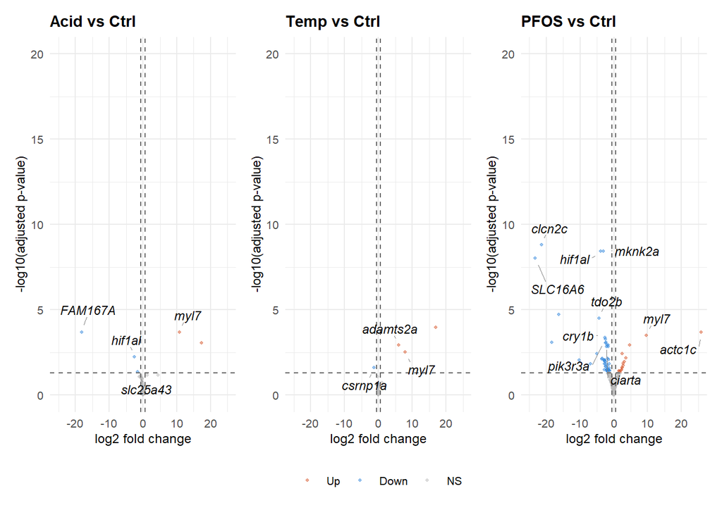

```r
# Single-stressor volcanoes for supplementary figure
p_volc_Acid_supp <- p_volc_Acid + coord_cartesian(xlim = c(-25, 25), ylim = c(0, 20))
p_volc_Temp_supp <- p_volc_Temp + coord_cartesian(xlim = c(-25, 25), ylim = c(0, 20))
p_volc_PFOS_supp <- p_volc_PFOS + coord_cartesian(xlim = c(-25, 25), ylim = c(0, 20))

supp_single_volcanoes <- (p_volc_Acid_supp + p_volc_Temp_supp + p_volc_PFOS_supp) +
  plot_layout(ncol = 3, guides = "collect") &
  theme(legend.position = "bottom")

supp_single_volcanoes
```

```r
ggsave("Supp_Figure_single_stressor_volcanoes.pdf",
       supp_single_volcanoes,
       width = 12, height = 4.5, units = "in", dpi = 300)
```

# Exposure replicate assessment for PFOSTemp

All three PFOSTemp female samples derive from exposure replicate 3. Since the two independent biological replicate experiments (exposures 2 and 3) differ by approximately one month in fish age at sampling, and exposure replicate was included as a covariate in the DESeq2 model, we assessed whether the strong PFOSTemp transcriptional signal might partly reflect experiment-specific variation rather than a genuine treatment effect. Note: this is not a sequencing batch effect in the technical sense and the two exposure replicates represent independent biological experiments with different fish, different tanks, and different breeding groups. However because all PFOSTemp samples come from one replicate, we cannot fully separate treatment effects from experiment-specific effects for this condition. To assess the biological origin of the PFOSTemp signal, we examined directional consistency of PFOSTemp DEGs with PFOS alone = a condition distributed across both exposure replicates (1 sample in replicate 2, 2 samples in replicate 3). If the PFOSTemp signal were driven by experiment-specific variation rather than biology, genes shared between PFOSTemp and PFOS would show random directional agreement. Consistent direction across both conditions would instead support a biological origin. We did the same analysis with Temp (2 samples in replicate 2, 2 samples in replicate 3).

```r
# Directional consistency of shared DEGs between PFOSTemp and PFOS

pfos_temp_genes <- results_PFOSTemp[
  results_PFOSTemp$direction %in% c("UP","DOWN"), "gene_id"]

pfos_genes <- results_PFOS[
  results_PFOS$direction %in% c("UP","DOWN"), "gene_id"]

shared <- pfos_temp_genes[pfos_temp_genes %in% pfos_genes]
cat("Genes significant in both PFOSTemp and PFOS:",
    length(shared), "\n")
```

```
## Genes significant in both PFOSTemp and PFOS: 33
```

```r
# Compare direction for shared genes
pfos_temp_dir <- results_PFOSTemp[
  results_PFOSTemp$gene_id %in% shared,
  c("gene_id", "direction")]

pfos_dir <- results_PFOS[
  results_PFOS$gene_id %in% shared,
  c("gene_id", "direction")]

dir_compare <- merge(pfos_temp_dir, pfos_dir,
                     by     = "gene_id",
                     suffixes = c("_PFOSTemp", "_PFOS"))

cat("Same direction:     ",
    sum(dir_compare$direction_PFOSTemp ==
        dir_compare$direction_PFOS),
    "/", nrow(dir_compare), "\n")
```

```
## Same direction:      33 / 33
```

```r
cat("Opposite direction: ",
    sum(dir_compare$direction_PFOSTemp !=
        dir_compare$direction_PFOS), "\n")
```

```
## Opposite direction:  0
```

```r
# Same test for Temp
temp_genes <- results_Temp[
  results_Temp$direction %in% c("UP","DOWN"), "gene_id"]

shared_temp <- pfos_temp_genes[pfos_temp_genes %in% temp_genes]
cat("\nGenes significant in both PFOSTemp and Temp:",
    length(shared_temp), "\n")
```

```
##
## Genes significant in both PFOSTemp and Temp: 1
```

```r
pfos_temp_dir2 <- results_PFOSTemp[
  results_PFOSTemp$gene_id %in% shared_temp,
  c("gene_id", "direction")]

temp_dir <- results_Temp[
  results_Temp$gene_id %in% shared_temp,
  c("gene_id", "direction")]

dir_compare_temp <- merge(pfos_temp_dir2, temp_dir,
                          by       = "gene_id",
                          suffixes = c("_PFOSTemp", "_Temp"))

cat("Same direction:     ",
    sum(dir_compare_temp$direction_PFOSTemp ==
        dir_compare_temp$direction_Temp),
    "/", nrow(dir_compare_temp), "\n")
```

```
## Same direction:      1 / 1
```

```r
cat("Opposite direction: ",
    sum(dir_compare_temp$direction_PFOSTemp !=
        dir_compare_temp$direction_Temp), "\n")
```

```
## Opposite direction:  0
```

Of the 33 genes significant in both PFOSTemp and PFOS, all 33 showed concordant direction of regulation (100% directional agreement). Under a random model, the probability of obtaining 33/33 concordant directions by chance is 0.5^33 = very low. This strongly supports a biological rather than experiment-specific origin for the shared component of the PFOSTemp signal.

The same test was performed for Temp but only 1 gene was shared between PFOSTemp and Temp DEG lists, which is insufficient to draw any conclusion about directional consistency. This reflects the very low number of DEGs detected in the Temp condition due to high within-group variance, rather than an absence of shared biology between Temp and PFOSTemp.

# Sensitivity analysis

```r
# Sensitivity analysis: all conditions vs Control
conditions <- c("Acid", "Temp", "PFOS",
                "AcidTemp", "PFOSTemp",
                "AcidPFOS", "APT")

# Extract results for all conditions
sens_results <- list()
for(cond in conditions) {

  # Skip if condition has no samples in sensitivity dataset
  if(!cond %in% levels(meta_f_sensitivity$condition)) {
    cat(cond, ": no samples in sensitivity dataset\n")
    next
  }

  res <- tryCatch({
    resLFC <- lfcShrink(dds_sensitivity_f,
                        contrast = c("condition", cond, "Ctrl"),
                        type = "ashr")
    get_sig_genes(resLFC, paste0(cond, "_sensitivity"))
  }, error = function(e) {
    cat(cond, ": error —", e$message, "\n")
    return(NULL)
  })

  sens_results[[cond]] <- res
}
```

```
## Acid : no samples in sensitivity dataset
## Temp : no samples in sensitivity dataset
## PFOS : no samples in sensitivity dataset
## AcidTemp : no samples in sensitivity dataset
## PFOSTemp : no samples in sensitivity dataset
## AcidPFOS : no samples in sensitivity dataset
## APT : no samples in sensitivity dataset
```

```r
# Compare main vs sensitivity DEG counts
cat("\nDEG comparison — main vs sensitivity analysis:\n")
```

```
##
## DEG comparison — main vs sensitivity analysis:
```

```r
cat(sprintf("%-12s %8s %8s %8s\n",
            "Condition", "Main", "Sensitivity", "Difference"))
```

```
## Condition        Main Sensitivity Difference
```

```r
cat(rep("-", 42), "\n", sep="")
for(cond in conditions) {
  main_n <- sum(get(paste0("results_", cond))$direction %in%
                  c("UP","DOWN"))

  sens_n <- if(!is.null(sens_results[[cond]])) {
    sum(sens_results[[cond]]$direction %in% c("UP","DOWN"))
  } else NA

  diff <- if(!is.na(sens_n)) sens_n - main_n else NA

  cat(sprintf("%-12s %8d %8s %8s\n",
              cond, main_n,
              ifelse(is.na(sens_n), "NA", as.character(sens_n)),
              ifelse(is.na(diff), "NA", as.character(diff))))
}
```

```
## Acid                5       NA       NA
## Temp                4       NA       NA
## PFOS               62       NA       NA
## AcidTemp          125       NA       NA
## PFOSTemp         2220       NA       NA
## AcidPFOS           74       NA       NA
## APT                96       NA       NA
```

```r
# Export all DEG results to Excel
wb <- createWorkbook()

# vs Control comparisons
for(nm in c("Acid","Temp","PFOS","AcidTemp",
            "PFOSTemp","AcidPFOS","APT")) {
  res <- get(paste0("results_", nm))
  sig <- res[res$direction %in% c("UP","DOWN"), ]
  addWorksheet(wb, nm)
  writeData(wb, nm, sig)
}

# Combination vs single stressor
for(nm in c("AcidTemp_vs_Acid","AcidTemp_vs_Temp",
            "PFOSTemp_vs_PFOS","PFOSTemp_vs_Temp",
            "AcidPFOS_vs_Acid","AcidPFOS_vs_PFOS",
            "APT_vs_Acid","APT_vs_Temp","APT_vs_PFOS",
            "APT_vs_AcidTemp","APT_vs_PFOSTemp",
            "APT_vs_AcidPFOS")) {
  res <- get(paste0("results_", nm))
  sig <- res[res$direction %in% c("UP","DOWN"), ]
  addWorksheet(wb, nm)
  writeData(wb, nm, sig)
}

saveWorkbook(wb, "DEG_results_all_comparisons.xlsx",
             overwrite = TRUE)

# Export KEGG GSEA results (Supplementary Table)
wb_kegg <- createWorkbook()
for(nm in names(kegg_list)) {
  g <- kegg_list[[nm]]
  if(!is.null(g) && nrow(g) > 0) {
    df <- as.data.frame(g)[, c("ID", "Description", "setSize",
                               "enrichmentScore", "NES",
                               "pvalue", "p.adjust", "qvalue",
                               "core_enrichment")]
    addWorksheet(wb_kegg, nm)
    writeData(wb_kegg, nm, df)
  }
}
saveWorkbook(wb_kegg, "KEGG_results_all_conditions.xlsx",
             overwrite = TRUE)

# Export GSEA results
wb_gsea <- createWorkbook()
for(nm in names(gsea_list)) {
  g <- gsea_list[[nm]]
  if(!is.null(g) && nrow(g) > 0) {
    df <- as.data.frame(g)[, c("Description", "setSize",
                                "enrichmentScore", "NES",
                                "pvalue", "p.adjust",
                                "core_enrichment")]
    addWorksheet(wb_gsea, nm)
    writeData(wb_gsea, nm, df)
  }
}
saveWorkbook(wb_gsea, "GSEA_results_all_conditions.xlsx",
             overwrite = TRUE)
```

```r
# Saves all key objects for fast session restore
save(counts, metadata,
     dds_explore,
     metadata, counts,
     dds_f, rld_f, pca_f,
     meta_f_main, counts_f_main,
     dds_main_f,
     results_Acid, results_Temp, results_PFOS,
     results_AcidTemp, results_PFOSTemp,
     results_AcidPFOS, results_APT,
     resLFC_Acid, resLFC_Temp, resLFC_PFOS,
     resLFC_AcidTemp, resLFC_PFOSTemp,
     resLFC_AcidPFOS, resLFC_APT,
     gsea_Acid, gsea_Temp, gsea_PFOS,
     gsea_AcidTemp, gsea_PFOSTemp,
     gsea_AcidPFOS, gsea_APT,
     gsea_list,
     file = "epiclim_analysis.RData")
```